# Abschlußprojekt für Data Analyst: Entwicklung eines Autopreisvorhersagemodells und Integration in ein Dashboard zur Anwendung.

## Autor: Guangfa Wu, 20.08.2025, Stuttgart

# Daten: https://www.kaggle.com/datasets/hellbuoy/car-price-prediction

# Projektidee, Beschreibung:

## Problembeschreibung: Autopreis vorhersagen

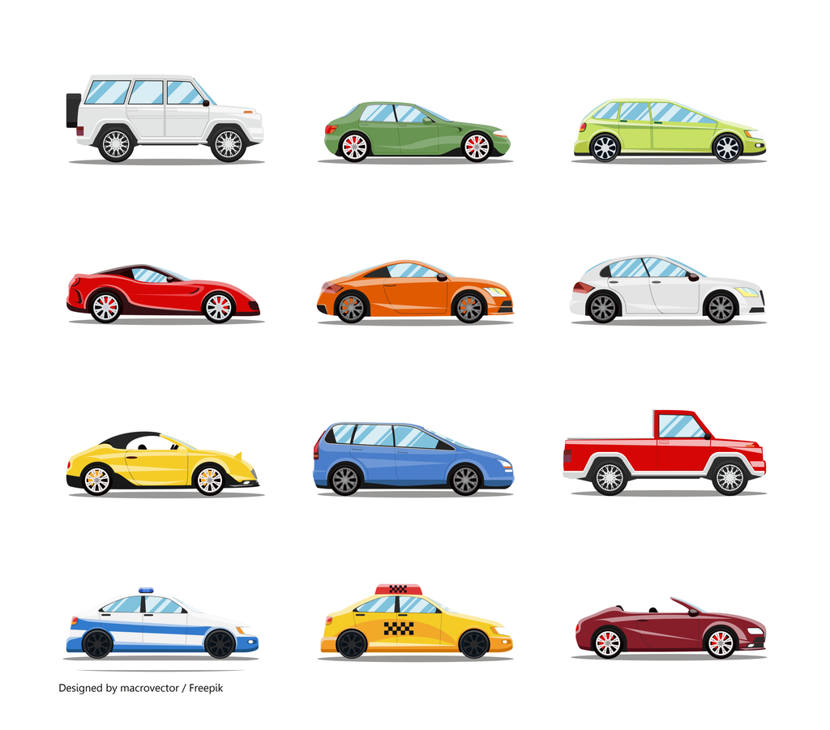

Ein chinesisches Automobilunternehmen, Geely Auto, plant den Eintritt in den US-amerikanischen Markt, indem es dort eine Produktionsstätte errichtet und Autos lokal herstellt, um mit amerikanischen und europäischen Konkurrenten zu konkurrieren. Dazu hat Geely ein Beratungsunternehmen für die Automobilbranche beauftragt, um die Faktoren zu analysieren, die den Preis von Autos beeinflussen. Insbesondere möchten sie verstehen, welche Faktoren den Preis von Autos auf dem amerikanischen Markt bestimmen, da diese sich deutlich vom chinesischen Markt unterscheiden könnten.

## Das Unternehmen möchte wissen:

- Welche Variablen sind signifikant für die Vorhersage des Autopreises?
- Wie gut erklären diese Variablen den Preis eines Autos?

## Vorgegensweise:

### CRISP-DM wird angewendet

Basierend auf verschiedenen Marktforschungen hat das Beratungsunternehmen einen umfangreichen Datensatz mit unterschiedlichen Fahrzeugtypen auf dem US-amerikanischen Markt zusammengetragen. Lösung der Aufgabestellung:

- Ein Modell soll entwickelt werden, das den Preis von Autos basierend auf den verfügbaren unabhängigen Variablen am besten vorhersagt. Da ein Auto aus verschieden Komponenten besteht, ist es nur sinnvoll, alle Komponenten zusammen zu betrachten und ein Preismodell zu erstellen.
- Gleichzeitig kann auch untersucht werden welche einzelnen Faktoren den Preis beeinflussen.
- Es wird ein Dashboard für Modelltraining durch Auswahl von beteiligten Spalten erstellt. Der Anwender kann selbst die Spalten auswählen und das Modell trainieren und das Ergebnis anzeigen und bewerten.

## Anwendung:

### Das Modell soll dem Management dabei helfen zu verstehen:

- Wie sich der Preis je nach Veränderung einzelner Merkmale verändert
- Welche Stellschrauben (Design, Strategie etc.) genutzt werden können, um bestimmte Preisniveaus zu erreichen.
- Zusätzlich ist das Modell ein hilfreiches Werkzeug, um die Preisdynamik in einem neuen Markt wie den USA zu verstehen.
- Es wird ein Dashboard erstellt. der Anwender kann selbst die einzelnen Parameter auswählen und den Preis abzuschätzen

### Der bereitgestellte Datensatz dient ausschließlich zu Lernzwecken. Ziehen keine Rückschlüsse auf reale Märkte oder tatsächliche Marktbedingungen.

# Die Arbeitsschritte richten sich nach CRISP-DM

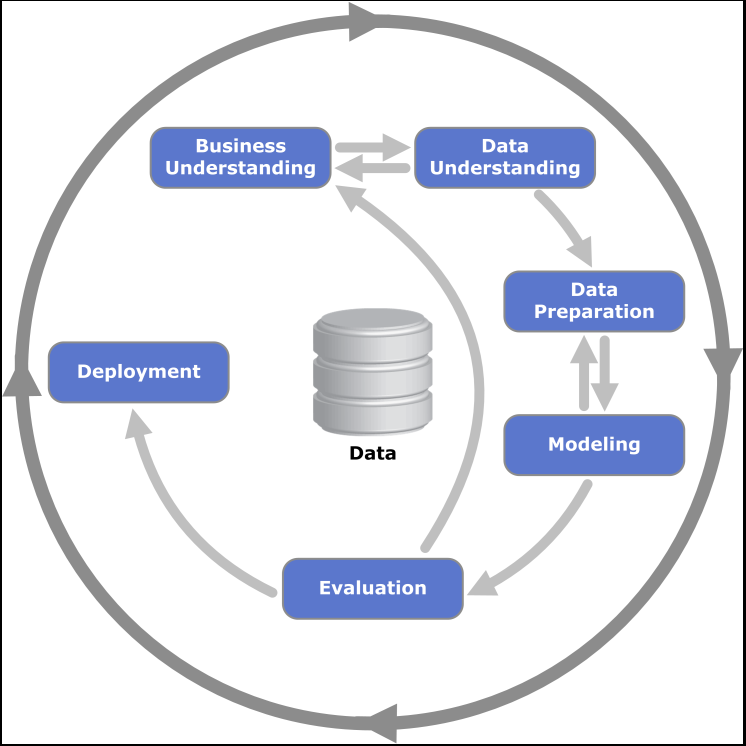

# 1. Business Understanding (Aufgabendefinition)

## Fahrzeugsegmente und Preisspannen

Das **Preissegment für Autos** wird üblicherweise in verschiedene Kategorien eingeteilt, die sich an der **Größe, Ausstattung und Komfort** des Fahrzeugs orientieren.  
Oft werden diese Segmente mit **Buchstaben (A, B, C, D, …)** bezeichnet und unterscheiden sich durch typische Preisspannen.

> Hinweis: Die Preisbereiche sind **Richtwerte** und können je nach Marke, Modell, Ausstattung und Region variieren.

### 🚗 Übersicht gängiger Fahrzeugsegmente

| **Fahrzeugsegment** | **Beschreibung** | **Typische Preisspanne (Neuwagen)** | **Bemerkungen zu Kosten** |
| --- | --- | --- | --- |
| **A-Segment** | Kleinstwagen, sehr kompakt, ideal für Stadtverkehr | unter 15.000 € | Günstig in Anschaffung und Unterhalt |
| **B-Segment** | Kleinwagen, etwas größer, alltagstauglicher, mehr Komfort | 15.000 – 25.000 € | Kompromiss zwischen Preis und Platz/Komfort |
| **C-Segment** | Kompaktklasse, familienfreundlich, gute Mischung aus Platz und Ausstattung | 20.000 – 35.000 € | Vielseitig, gute Ausstattung |
| **D-Segment** | Mittelklasse, komfortabler, bessere Ausstattung | ab ca. 35.000 € | Höhere Anschaffungskosten |
| **Oberklasse / Luxus** | Große und luxuriöse Fahrzeuge | ab ca. 50.000 € | Teuer, höherer Unterhalt, Luxusausstattung |

### Relevanz für die Analyse

In der Aufgabenstellung gibt der Hersteller **keine Informationen**, auf welches Preissegment er sich fokussieren möchte.  
Als **Data Analyst** ist es daher notwendig:

- Mit dem Auftraggeber zu kommunizieren, um die **Anforderungen und Geschäftsziele** genau zu verstehen.
- Klarzustellen, ob die **Vorhersage für den Gesamtmarkt** oder für ein **bestimmtes Preissegment** erfolgen soll.
- Auf Basis der gewählten Segmente die **Preisvorhersagen gezielt** an die jeweilige Kategorie anzupassen.

## Datenquelle:

### [CarPrice_Assignment.csv](https://www.kaggle.com/datasets/hellbuoy/car-price-prediction/)

### Information von Auto: 26 Spalten

- **car_ID**: Identification Number for Each Car
- **symbling**: Car's Safety Rating (-3 (sehr sicher) bis +3 (hohes Risiko).
- **CarName**: Name of the Car Model
- **fueltype**: Type of Fuel Used (Gasoline, Diesel, Electric, etc.)
- **aspiration**: Type of Aspiration (Standard or Turbocharged)
- **doornumber**: Number of Doors on the Car
- **carbody**: Style of the Car's Body (Sedan, Coupe, SUV, etc.)
- **drivewheel**: Type of Drive Wheels (Front, Rear, All)
- **enginelocation**: Location of the Car's Engine (Front or Rear)
- **wheelbase**: Length of the Car's Wheelbase
- **carlength**: Overall Length of the Car
- **carwidth**: Width of the Car
- **carheight**: Height of the Car
- **curbweight**: Weight of the Car without Passengers or Cargo
- **enginetype**: Type of Engine (Gas, Diesel, Electric, etc.)
- **cylindernumber**: Number of Cylinders in the Engine
- **enginesize**: Size of the Car's Engine
- **fuelsystem**: Type of Fuel Delivery System
- **boreratio**: Bore-to-Stroke Ratio of the Engine
- **stroke**: Stroke Length of the Engine
- **compressionratio**: Compression Ratio of the Engine
- **horsepower**: Car's Engine Horsepower
- **peakrpm**: Engine's Peak RPM (Revolutions Per Minute)
- **citympg**: Miles Per Gallon (MPG) in City Driving
- **highwaympg**: MPG on the Highway
- **price**: Price of the Car

```python
# import packages

import pandas as pd
import numpy as np
import json
import math
import matplotlib
from datetime import timedelta, datetime
import matplotlib.pyplot as plt
import matplotlib.mlab as mlab
from matplotlib.pyplot import figure
from datetime import date

import plotly.express as px
from plotly.subplots import make_subplots
import plotly.graph_objects as go


plt.style.use('seaborn-v0_8-notebook')
%matplotlib inline
matplotlib.rcParams['figure.figsize'] = (12,8)
pd.options.mode.chained_assignment = None
import seaborn as sns
```

## Einlesen von Daten aus der csv-Datei:

```python
# Einlesen von Daten
df = pd.read_csv("CarPrice_Assignment.csv")
door_mapCt=0     # um mehrfach map zu vermeiden
door_mapCt1=0  # um mehrfach map zu vermeiden
pd.set_option('display.max_columns', None) # zeigt alle Spalten an
```

# 2. Data Understanding (Auswahl der relevanten Datenbestände)

## 2.1 Deskriptive Analyse

Bei der **deskriptiven Analyse** werden die Daten mithilfe einfacher statistischer Methoden untersucht, um einen Überblick über die **Datenstruktur, Verteilungen und Zusammenhänge** zu erhalten.

Das Ziel ist es, die **Eigenschaften der Daten** zu beschreiben, z. B.:

- Mittelwerte
- Streuung (Standardabweichung, Varianz)
- Häufigkeiten
- Verteilungen

Wichtig: Es geht **nicht** um Vorhersagen oder Ursache-Wirkungs-Beziehungen, sondern um ein erstes Verständnis der Daten.

### Erste Methoden für einen Überblick

- **`df.head()`** → zeigt die ersten Zeilen der Daten
- **`df.info()`** → Überblick über Datentypen und fehlende Werte
- **`df.describe()`** → zentrale statistische Kennzahlen (Mittelwert, Min, Max, Quartile)
- **`df.nunique()`** → Anzahl der eindeutigen Werte pro Spalte
- **Wertverteilungen** mit **`value_counts()`** für kategoriale Spalten

Diese Methoden liefern schnell ein klares Bild über die Struktur und Qualität der Daten.

| Methode | Zweck / Was sie zeigt | Warum sinnvoll für Data Analysts |
| --- | --- | --- |
| `df.info()` | Gibt Spaltennamen, Datentypen, Anzahl nicht fehlender Werte und Speicherverbrauch aus | Schneller Überblick über Datentypen, fehlende Werte und Speicherbedarf. Hilft bei der Datenvorbereitung. |
| `df.describe()` | Statistische Kennzahlen numerischer Spalten: count, mean, std, min, 25%, 50%, 75%, max | Erkennt Verteilungen, Ausreißer und zentrale Tendenzen. Grundlage für Transformationen und Feature Engineering. |
| `df.nunique()` | Anzahl der eindeutigen Werte pro Spalte | Identifikation von kategorialen Spalten, Variabilität von Features, Erkennen von konstanten oder redundanten Spalten. |
| `df.isna().sum()` | Anzahl der fehlenden Werte (`NaN`) pro Spalte | Hilft, Spalten mit fehlenden Daten schnell zu identifizieren, Planung von Imputation oder Bereinigung der Daten. |

```python
# Ein Überblick über die Daten mit df.head()
df.head(15)
```

|  | car_ID | symboling | CarName | fueltype | aspiration | doornumber | carbody | drivewheel | enginelocation | wheelbase | carlength | carwidth | carheight | curbweight | enginetype | cylindernumber | enginesize | fuelsystem | boreratio | stroke | compressionratio | horsepower | peakrpm | citympg | highwaympg | price |
| --- | --- | --- | --- | --- | --- | --- | --- | --- | --- | --- | --- | --- | --- | --- | --- | --- | --- | --- | --- | --- | --- | --- | --- | --- | --- | --- |
| 0 | 1 | 3 | alfa-romero giulia | gas | std | two | convertible | rwd | front | 88.6 | 168.8 | 64.1 | 48.8 | 2548 | dohc | four | 130 | mpfi | 3.47 | 2.68 | 9.0 | 111 | 5000 | 21 | 27 | 13495.000 |
| 1 | 2 | 3 | alfa-romero stelvio | gas | std | two | convertible | rwd | front | 88.6 | 168.8 | 64.1 | 48.8 | 2548 | dohc | four | 130 | mpfi | 3.47 | 2.68 | 9.0 | 111 | 5000 | 21 | 27 | 16500.000 |
| 2 | 3 | 1 | alfa-romero Quadrifoglio | gas | std | two | hatchback | rwd | front | 94.5 | 171.2 | 65.5 | 52.4 | 2823 | ohcv | six | 152 | mpfi | 2.68 | 3.47 | 9.0 | 154 | 5000 | 19 | 26 | 16500.000 |
| 3 | 4 | 2 | audi 100 ls | gas | std | four | sedan | fwd | front | 99.8 | 176.6 | 66.2 | 54.3 | 2337 | ohc | four | 109 | mpfi | 3.19 | 3.40 | 10.0 | 102 | 5500 | 24 | 30 | 13950.000 |
| 4 | 5 | 2 | audi 100ls | gas | std | four | sedan | 4wd | front | 99.4 | 176.6 | 66.4 | 54.3 | 2824 | ohc | five | 136 | mpfi | 3.19 | 3.40 | 8.0 | 115 | 5500 | 18 | 22 | 17450.000 |
| 5 | 6 | 2 | audi fox | gas | std | two | sedan | fwd | front | 99.8 | 177.3 | 66.3 | 53.1 | 2507 | ohc | five | 136 | mpfi | 3.19 | 3.40 | 8.5 | 110 | 5500 | 19 | 25 | 15250.000 |
| 6 | 7 | 1 | audi 100ls | gas | std | four | sedan | fwd | front | 105.8 | 192.7 | 71.4 | 55.7 | 2844 | ohc | five | 136 | mpfi | 3.19 | 3.40 | 8.5 | 110 | 5500 | 19 | 25 | 17710.000 |
| 7 | 8 | 1 | audi 5000 | gas | std | four | wagon | fwd | front | 105.8 | 192.7 | 71.4 | 55.7 | 2954 | ohc | five | 136 | mpfi | 3.19 | 3.40 | 8.5 | 110 | 5500 | 19 | 25 | 18920.000 |
| 8 | 9 | 1 | audi 4000 | gas | turbo | four | sedan | fwd | front | 105.8 | 192.7 | 71.4 | 55.9 | 3086 | ohc | five | 131 | mpfi | 3.13 | 3.40 | 8.3 | 140 | 5500 | 17 | 20 | 23875.000 |
| 9 | 10 | 0 | audi 5000s (diesel) | gas | turbo | two | hatchback | 4wd | front | 99.5 | 178.2 | 67.9 | 52.0 | 3053 | ohc | five | 131 | mpfi | 3.13 | 3.40 | 7.0 | 160 | 5500 | 16 | 22 | 17859.167 |
| 10 | 11 | 2 | bmw 320i | gas | std | two | sedan | rwd | front | 101.2 | 176.8 | 64.8 | 54.3 | 2395 | ohc | four | 108 | mpfi | 3.50 | 2.80 | 8.8 | 101 | 5800 | 23 | 29 | 16430.000 |
| 11 | 12 | 0 | bmw 320i | gas | std | four | sedan | rwd | front | 101.2 | 176.8 | 64.8 | 54.3 | 2395 | ohc | four | 108 | mpfi | 3.50 | 2.80 | 8.8 | 101 | 5800 | 23 | 29 | 16925.000 |
| 12 | 13 | 0 | bmw x1 | gas | std | two | sedan | rwd | front | 101.2 | 176.8 | 64.8 | 54.3 | 2710 | ohc | six | 164 | mpfi | 3.31 | 3.19 | 9.0 | 121 | 4250 | 21 | 28 | 20970.000 |
| 13 | 14 | 0 | bmw x3 | gas | std | four | sedan | rwd | front | 101.2 | 176.8 | 64.8 | 54.3 | 2765 | ohc | six | 164 | mpfi | 3.31 | 3.19 | 9.0 | 121 | 4250 | 21 | 28 | 21105.000 |
| 14 | 15 | 1 | bmw z4 | gas | std | four | sedan | rwd | front | 103.5 | 189.0 | 66.9 | 55.7 | 3055 | ohc | six | 164 | mpfi | 3.31 | 3.19 | 9.0 | 121 | 4250 | 20 | 25 | 24565.000 |

### 2.1.1 Die Methode `df.info()` in Pandas

Die Methode **`df.info()`** gibt einen **kompakten Überblick über den DataFrame**.  
Sie zeigt für jede Spalte:

- **Spaltenname**
- **Anzahl der nicht fehlenden Werte (Non-Null Count)**
- **Datentyp (`dtype`)**
- **Speicherverbrauch des DataFrames**

### Ergebnisse für die Projektdaten

1. Es gibt **26 Spalten** und **205 Zeilen**.
2. Es gibt **keine fehlenden Werte (NaN)**.
3. Die Spalten **`doornumber`** und **`cylindernumber`** werden als **`object`** (Text) dargestellt.
   - Dies sollte untersucht werden, da sie eigentlich **numerische Werte** (Anzahl der Türen bzw. Zylinder) enthalten sollten.
   - Möglicher Grund: Werte könnten als **Strings** gespeichert sein (z. B. `"four"` statt `4`).

```python
# zeige die kompakte Information über die Daten
df.info()
```

```
<class 'pandas.core.frame.DataFrame'>
RangeIndex: 205 entries, 0 to 204
Data columns (total 26 columns):
 #   Column            Non-Null Count  Dtype
---  ------            --------------  -----
 0   car_ID            205 non-null    int64
 1   symboling         205 non-null    int64
 2   CarName           205 non-null    object
 3   fueltype          205 non-null    object
 4   aspiration        205 non-null    object
 5   doornumber        205 non-null    object
 6   carbody           205 non-null    object
 7   drivewheel        205 non-null    object
 8   enginelocation    205 non-null    object
 9   wheelbase         205 non-null    float64
```

[output cut: 18 more lines]

### 2.1.2 Check NAN: Ergebnis:keine NaN vorhanden. Die Behandlung von NaN entfällt.

```python
# Prüfen wie viele Nan jeder Spalte gibt: zwar df.info() hat gezeigt es keine NAN gibt. es ist üblich df.isna().sum() auch mal zu benutzen
# df.isnull().sum()
df.isna().sum()
```

```
car_ID              0
symboling           0
CarName             0
fueltype            0
aspiration          0
doornumber          0
carbody             0
drivewheel          0
enginelocation      0
wheelbase           0
carlength           0
carwidth            0
carheight           0
curbweight          0
enginetype          0
cylindernumber      0
enginesize          0
fuelsystem          0
boreratio           0
stroke              0
compressionratio    0
horsepower          0
peakrpm             0
citympg             0
highwaympg          0
price               0
dtype: int64
```

### 2.1.3 Untersuchung von cylindernumber und doornumber: sind als Kategorie angegeben, in Zahl umwandeln

1. Es ist anzunehmen, dass vier Tür mehr als zwei Tür kostet. ['two' 'four'] in Zahlen: 2, 4
2. Es ist anzunehmen, dass der Preis mit der Anzahl der Zylinder steigt. ['four', 'six', 'five', 'three', 'twelve', 'two', 'eight']: z.B. 'two' in 2, 'twelve' in 12 umwandeln: 2,3,4,5,6,8,12

```python
# zeige welche Anzahl von Tür ein Auto hat. z.B. 2,3,5
# zeige auch die Anzahl von Autos  von 2 und 4 Türen
print(df.doornumber.unique())
print(df.groupby(['doornumber']).count())
df.groupby(['doornumber']).mean(numeric_only=True)
```

```
['two' 'four']
            car_ID  symboling  CarName  fueltype  aspiration  carbody  \
doornumber
four           115        115      115       115         115      115
two             90         90       90        90          90       90

            drivewheel  enginelocation  wheelbase  carlength  carwidth  \
doornumber
four               115             115        115        115       115
two                 90              90         90         90        90

            carheight  curbweight  enginetype  cylindernumber  enginesize  \
doornumber
four              115         115         115             115         115
two                90          90          90              90          90

            fuelsystem  boreratio  stroke  compressionratio  horsepower  \
doornumber
four               115        115     115               115         115
two                 90         90      90                90          90

            peakrpm  citympg  highwaympg  price
doornumber
four            115      115         115    115
two              90       90          90     90
```

| doornumber | car_ID | symboling | wheelbase | carlength | carwidth | carheight | curbweight | enginesize | boreratio | stroke | compressionratio | horsepower | peakrpm | citympg | highwaympg | price |
| --- | --- | --- | --- | --- | --- | --- | --- | --- | --- | --- | --- | --- | --- | --- | --- | --- |
| four | 112.965217 | 0.104348 | 101.133913 | 178.388696 | 66.300000 | 54.915652 | 2646.260870 | 127.669565 | 3.358261 | 3.252348 | 10.766087 | 99.686957 | 5020.869565 | 25.147826 | 30.530435 | 13501.152174 |
| two | 90.266667 | 1.766667 | 95.718889 | 168.504444 | 65.406667 | 52.203333 | 2439.677778 | 125.933333 | 3.293333 | 3.259333 | 9.345778 | 109.777778 | 5258.333333 | 25.311111 | 31.033333 | 12989.924078 |

```python
# zeige welche Zylinder Kategorie es gibt
df.cylindernumber.unique()
```

```
array(['four', 'six', 'five', 'three', 'twelve', 'two', 'eight'],
      dtype=object)
```

```python
# wie schon erwähnt. es ist sinnvoll, Anzahl von Tür und Zylinder in Zahl umzuwandeln
map_list= {'two':2,'three':3,'four':4, 'five':5,'six':6,'eight':8,'twelve':12}
if( door_mapCt1==0): #verhindern nochmaliges Umwandeln
  df['cylindernumber'] = df['cylindernumber'].map(map_list).astype(int)
  df['doornumber'] = df['doornumber'].map(map_list).astype(int)

door_mapCt1=1
print(df.cylindernumber)
print(df.doornumber)
```

```
0      4
1      4
2      6
3      4
4      5
      ..
200    4
201    4
202    6
203    6
204    4
Name: cylindernumber, Length: 205, dtype: int64
0      2
1      2
2      2
3      4
4      4
      ..
200    4
201    4
202    4
203    4
204    4
Name: doornumber, Length: 205, dtype: int64
```

### Anwendungvon `df.describe()`

Die Methode **`df.describe()`** in Pandas liefert eine **statistische Zusammenfassung** der numerischen Spalten eines DataFrames.  
Standardmäßig zeigt sie folgende Kennzahlen:

- **count**: Anzahl der nicht fehlenden Werte
- **mean**: Mittelwert der Spalte
- **std**: Standardabweichung
- **min**: Minimalwert
- **25%**, **50%**, **75%**: Quartile (25%, Median, 75%)
- **max**: Maximalwert

### Warum ist `df.describe()` sinnvoll für Data Analysts?

#### 1. Schneller Überblick über die Daten

Man sieht sofort Mittelwerte, Streuung, Minimal- und Maximalwerte.

#### 2. Datenqualität prüfen

Wenn **count** für eine Spalte kleiner als die Anzahl der Zeilen ist, gibt es fehlende Werte (`NaN` oder `None`).

#### 3. Vergleich zwischen Spalten

Beispiel: `citympg` und `highwaympg`

- `df.describe()` ermöglicht es, schnell zu erkennen, welche Spalten stark variieren und welche konstant sind.
- Man kann erste Korrelationen und Ähnlichkeiten zwischen Spalten identifizieren.

```python
# zeige die statistische Zusammenfassung
df.describe()
```

|  | car_ID | symboling | doornumber | wheelbase | carlength | carwidth | carheight | curbweight | cylindernumber | enginesize | boreratio | stroke | compressionratio | horsepower | peakrpm | citympg | highwaympg | price |
| --- | --- | --- | --- | --- | --- | --- | --- | --- | --- | --- | --- | --- | --- | --- | --- | --- | --- | --- |
| count | 205.000000 | 205.000000 | 205.000000 | 205.000000 | 205.000000 | 205.000000 | 205.000000 | 205.000000 | 205.000000 | 205.000000 | 205.000000 | 205.000000 | 205.000000 | 205.000000 | 205.000000 | 205.000000 | 205.000000 | 205.000000 |
| mean | 103.000000 | 0.834146 | 3.121951 | 98.756585 | 174.049268 | 65.907805 | 53.724878 | 2555.565854 | 4.380488 | 126.907317 | 3.329756 | 3.255415 | 10.142537 | 104.117073 | 5125.121951 | 25.219512 | 30.751220 | 13276.710571 |
| std | 59.322565 | 1.245307 | 0.994966 | 6.021776 | 12.337289 | 2.145204 | 2.443522 | 520.680204 | 1.080854 | 41.642693 | 0.270844 | 0.313597 | 3.972040 | 39.544167 | 476.985643 | 6.542142 | 6.886443 | 7988.852332 |
| min | 1.000000 | -2.000000 | 2.000000 | 86.600000 | 141.100000 | 60.300000 | 47.800000 | 1488.000000 | 2.000000 | 61.000000 | 2.540000 | 2.070000 | 7.000000 | 48.000000 | 4150.000000 | 13.000000 | 16.000000 | 5118.000000 |
| 25% | 52.000000 | 0.000000 | 2.000000 | 94.500000 | 166.300000 | 64.100000 | 52.000000 | 2145.000000 | 4.000000 | 97.000000 | 3.150000 | 3.110000 | 8.600000 | 70.000000 | 4800.000000 | 19.000000 | 25.000000 | 7788.000000 |
| 50% | 103.000000 | 1.000000 | 4.000000 | 97.000000 | 173.200000 | 65.500000 | 54.100000 | 2414.000000 | 4.000000 | 120.000000 | 3.310000 | 3.290000 | 9.000000 | 95.000000 | 5200.000000 | 24.000000 | 30.000000 | 10295.000000 |
| 75% | 154.000000 | 2.000000 | 4.000000 | 102.400000 | 183.100000 | 66.900000 | 55.500000 | 2935.000000 | 4.000000 | 141.000000 | 3.580000 | 3.410000 | 9.400000 | 116.000000 | 5500.000000 | 30.000000 | 34.000000 | 16503.000000 |
| max | 205.000000 | 3.000000 | 4.000000 | 120.900000 | 208.100000 | 72.300000 | 59.800000 | 4066.000000 | 12.000000 | 326.000000 | 3.940000 | 4.170000 | 23.000000 | 288.000000 | 6600.000000 | 49.000000 | 54.000000 | 45400.000000 |

### Überblick über die Anzahl der eindeutigen Werte (`unique values`)

Die Methode **`df.nunique()`** in Pandas gibt die Anzahl der **eindeutigen Werte** jeder Spalte eines DataFrames zurück.

### Warum ist `df.nunique()` sinnvoll für die Datenanalyse?

1. **Identifikation von kategorialen Spalten**
   - Spalten mit wenigen eindeutigen Werten sind oft kategorial (z. B. Geschlecht, Region).
   - Erkennt Variabilität in numerischen Spalten → wenn eine numerische Spalte nur wenige eindeutige Werte hat, könnte sie diskret oder ein Dummy-Feature sein.
2. **Datenbereinigung und Feature Engineering**
   - Hilft, redundante Spalten oder Spalten mit konstanten Werten zu erkennen.
   - Unterstützt Entscheidungen für Encoding-Strategien, z. B. **One-Hot-Encoding** oder **Ordinal-Encoding**.
3. **Schneller Überblick über die Datenstruktur**
   - Data Analysts bekommen sofort ein Gefühl dafür, wie divers die Werte in jeder Spalte sind,  
     ohne alle Daten einzeln prüfen zu müssen.

```python
# Überblick über die Anzahl der eindeutigen Werte
df.nunique()
```

```
car_ID              205
symboling             6
CarName             147
fueltype              2
aspiration            2
doornumber            2
carbody               5
drivewheel            3
enginelocation        2
wheelbase            53
carlength            75
carwidth             44
carheight            49
curbweight          171
enginetype            7
cylindernumber        7
enginesize           44
fuelsystem            8
boreratio            38
stroke               37
compressionratio     32
horsepower           59
peakrpm              23
citympg              29
highwaympg           30
price               189
dtype: int64
```

### 2.1.4 Erstellung von Histogrammen für numerische Werte

Ein **Histogramm** stellt die **Häufigkeitsverteilung** der Werte einer numerischen Spalte grafisch dar.  
Die Werte werden in sogenannte **Bins** (Intervalle) unterteilt, und für jedes Intervall wird angezeigt, wie viele Datenpunkte darin liegen.

Mit Histogrammen kann man auf einen Blick erkennen:

- die **Verteilung** der Daten (gleichmäßig, schief, normalverteilt, etc.),
- das Vorhandensein von **Ausreißern** oder ungewöhnlichen Werten (**Grenze: -3*std < x < +3*std**),
- **Symmetrie oder Asymmetrie** der Datenverteilung.

Für Data Analysts ist dies sinnvoll, da Histogramme helfen, die Daten **besser zu verstehen**, die Wahl geeigneter **Transformationen** zu planen (z. B. log, sqrt) und **Vorverarbeitungsmaßnahmen** für Machine-Learning-Modelle abzuleiten.

#### 2.1.4.1 Analyse der Histogramme der Fahrzeugmerkmale

Die bereitgestellten Histogramme geben einen Überblick über die Verteilung verschiedener numerischer Merkmale im Datensatz.

#### 2.1.4.2 Zusammenfassende Beobachtungen

- **Rechtsschiefe Verteilungen:** Viele Merkmale (z.B. Zylinderzahl, Motorgröße, Leistung, Curbweight, City/Highway MPG) weisen rechtsschiefe Verteilungen auf. Hohe Werte sind selten.
- **Kategoriale/Diskrete Werte:** "Symboling" und "doornumber" sind diskret oder kategorial.
- **Normalverteilungsähnlichkeit:** Merkmale wie "wheelbase", "carlength", "carwidth", "peakrpm", "stroke" ähneln einer Normalverteilung.
- **Bimodale Verteilungen:** "doornumber" und "compressionratio" zeigen zwei Gruppen (z.B. 2- vs. 4-türige Autos, Benzin- vs. Diesel-Motoren).

**Fazit:**  
Die Histogramme liefern einen wertvollen Überblick über die Verteilung der Fahrzeugmerkmale, helfen, Ausreißer zu erkennen und identifizieren typische Wertebereiche sowie gemeinsame Muster im Datensatz.

```
16
```

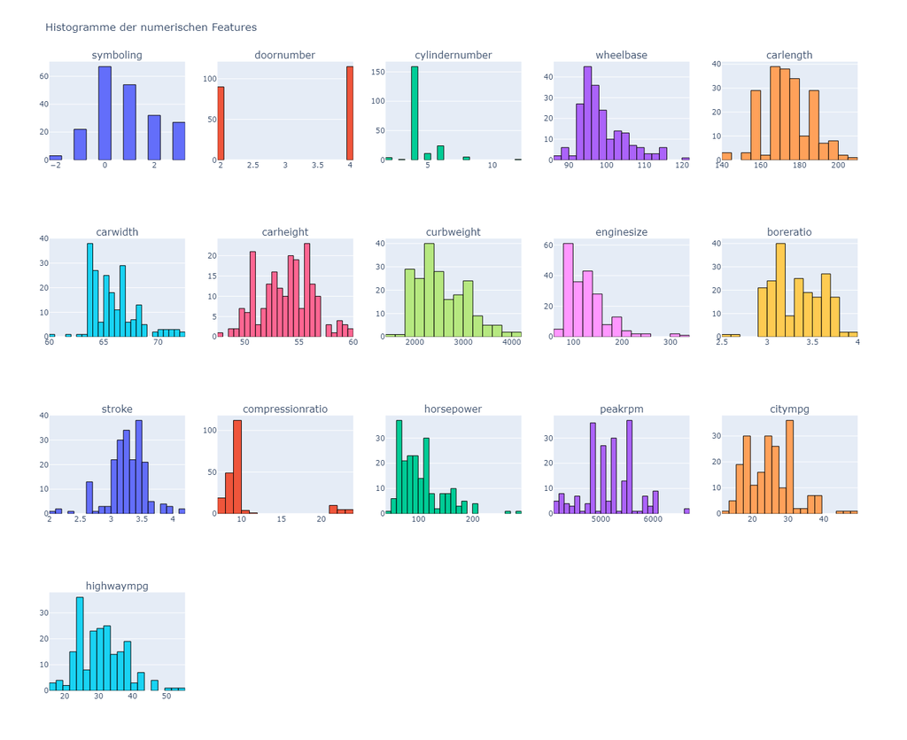

```python
# Feature engneering:
# Histogram für numerische Werte erstellen und darstellen
numerical_columns = ['symboling','doornumber','cylindernumber','wheelbase', 'carlength', 'carwidth', 'carheight', 'curbweight',
                     'enginesize', 'boreratio', 'stroke', 'compressionratio', 'horsepower',
                     'peakrpm', 'citympg', 'highwaympg']
print(len(numerical_columns))
cols = 5
rows = int(np.ceil(len(numerical_columns) / cols))

fig = make_subplots(rows=rows, cols=cols, subplot_titles=numerical_columns)

for i, feature in enumerate(numerical_columns):
    row = i // cols + 1
    col = i % cols + 1
    #print("row, col", row, col)
    fig.add_trace(
    go.Histogram(
        x=df[feature],
        nbinsx=25,
        name=feature,
        marker=dict(
            line=dict(
                color='black',  # Linienfarbe
                width=1         # Liniendicke
            )
        )
    ),
    row=row, col=col
    )


fig.update_layout(
    height=300 * rows,
    width=1400,
    title_text="Histogramme der numerischen Features",
    showlegend=False
)

fig.show()
```

### 2.1.5 Histogram von Autopreisen: hier von besonderem Interesse

Es geht um folgende Rahmenkennzahlen der Autopreise

#### Min.: 5118€

#### Max.: 45400€

#### mean: 13276€

#### midian: 10295€

Es ist zu erkennen, dass die meisten Autos im Preisbereich zwischen **6.000 und 20.000 $** liegen.  
Das bedeutet, dass die Daten überwiegend Fahrzeuge aus dem **niedrigen und mittleren Preissegment** abbilden.  
Daraus lässt sich schließen, dass die Modellierung und die Preisvorhersage in erster Linie auf diese Segmente ausgelegt ist.

Für das **hochpreisige Segment** sind dagegen deutlich weniger Datenpunkte vorhanden, was die Prognosegenauigkeit in diesem Bereich einschränken kann.

Auf Grundlage dieser Erkenntnisse muss entschieden werden, ob die Daten für das **hochpreisige Segment** überhaupt sinnvoll für die Modellierung und Preisvorhersage genutzt werden können.

Da in diesem Bereich nur sehr wenige Datenpunkte vorliegen, besteht die Gefahr, dass das Modell hier keine zuverlässigen Zusammenhänge lernen kann.  
Dies kann die **Qualität und Aussagekraft des Modells** im oberen Preissegment deutlich verschlechtern und zu **ungenauen oder verzerrten Vorhersagen** führen.

Eine mögliche Konsequenz wäre, das Modell bewusst auf das **niedrige und mittlere Preissegment** zu beschränken oder für das hochpreisige Segment zusätzliche Datenquellen zu erschließen.

```
-- Überblick über statistische Werte von Preis --
min.: 5118.0
max.: 45400.0
mean: 13276.710570731706
median: 10295.0
```

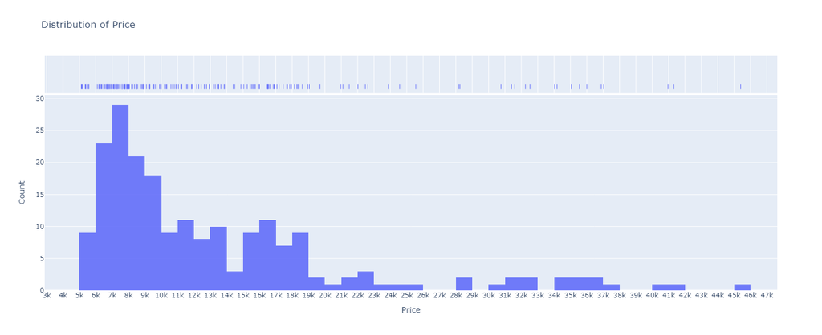

```python
# Analyse von Preis: Histogram für Preise

print("-- Überblick über statistische Werte von Preis --")

print("min.:", df['price'].min())
print("max.:",df['price'].max())
print("mean:",df['price'].mean())
print("median:",df['price'].median())


fig = px.histogram(df, x='price', nbins=50, marginal="rug", title='Distribution of Price', opacity=0.9)
#fig = px.histogram(df, x='price', nbins=40, title='Distribution of Price', opacity=0.8)

fig.update_layout(
    xaxis_title='Price',
    yaxis_title='Count',
    height=600  # Höhe des Plots
)

fig.update_xaxes(
    tickmode='linear',
    tick0=0,
    dtick=1000
)

fig.show()
```

### 2.1.6 Bar-Darstellung der kategorischen Daten

```python
print(df['fuelsystem'].unique())
print(df['aspiration'].unique())
print(df['carbody'].unique())
print(df['drivewheel'].unique())
print(df['enginelocation'].unique())
print(df['enginetype'].unique())
print()
print(df['CarName'].unique())
```

```
['mpfi' '2bbl' 'mfi' '1bbl' 'spfi' '4bbl' 'idi' 'spdi']
['std' 'turbo']
['convertible' 'hatchback' 'sedan' 'wagon' 'hardtop']
['rwd' 'fwd' '4wd']
['front' 'rear']
['dohc' 'ohcv' 'ohc' 'l' 'rotor' 'ohcf' 'dohcv']

['alfa-romero giulia' 'alfa-romero stelvio' 'alfa-romero Quadrifoglio'
 'audi 100 ls' 'audi 100ls' 'audi fox' 'audi 5000' 'audi 4000'
 'audi 5000s (diesel)' 'bmw 320i' 'bmw x1' 'bmw x3' 'bmw z4' 'bmw x4'
 'bmw x5' 'chevrolet impala' 'chevrolet monte carlo' 'chevrolet vega 2300'
 'dodge rampage' 'dodge challenger se' 'dodge d200' 'dodge monaco (sw)'
 'dodge colt hardtop' 'dodge colt (sw)' 'dodge coronet custom'
 'dodge dart custom' 'dodge coronet custom (sw)' 'honda civic'
 'honda civic cvcc' 'honda accord cvcc' 'honda accord lx'
 'honda civic 1500 gl' 'honda accord' 'honda civic 1300' 'honda prelude'
 'honda civic (auto)' 'isuzu MU-X' 'isuzu D-Max ' 'isuzu D-Max V-Cross'
 'jaguar xj' 'jaguar xf' 'jaguar xk' 'maxda rx3' 'maxda glc deluxe'
 'mazda rx2 coupe' 'mazda rx-4' 'mazda glc deluxe' 'mazda 626' 'mazda glc'
 'mazda rx-7 gs' 'mazda glc 4' 'mazda glc custom l' 'mazda glc custom'
 'buick electra 225 custom' 'buick century luxus (sw)' 'buick century'
 'buick skyhawk' 'buick opel isuzu deluxe' 'buick skylark'
 'buick century special' 'buick regal sport coupe (turbo)'
 'mercury cougar' 'mitsubishi mirage' 'mitsubishi lancer'
 'mitsubishi outlander' 'mitsubishi g4' 'mitsubishi mirage g4'
 'mitsubishi montero' 'mitsubishi pajero' 'Nissan versa' 'nissan gt-r'
 'nissan rogue' 'nissan latio' 'nissan titan' 'nissan leaf' 'nissan juke'
 'nissan note' 'nissan clipper' 'nissan nv200' 'nissan dayz' 'nissan fuga'
 'nissan otti' 'nissan teana' 'nissan kicks' 'peugeot 504' 'peugeot 304'
 'peugeot 504 (sw)' 'peugeot 604sl' 'peugeot 505s turbo diesel'
 'plymouth fury iii' 'plymouth cricket' 'plymouth satellite custom (sw)'
 'plymouth fury gran sedan' 'plymouth valiant' 'plymouth duster'
 'porsche macan' 'porcshce panamera' 'porsche cayenne' 'porsche boxter'
 'renault 12tl' 'renault 5 gtl' 'saab 99e' 'saab 99le' 'saab 99gle'
 'subaru' 'subaru dl' 'subaru brz' 'subaru baja' 'subaru r1' 'subaru r2'
 'subaru trezia' 'subaru tribeca' 'toyota corona mark ii' 'toyota corona'
 'toyota corolla 1200' 'toyota corona hardtop' 'toyota corolla 1600 (sw)'
 'toyota carina' 'toyota mark ii' 'toyota corolla'
 'toyota corolla liftback' 'toyota celica gt liftback'
 'toyota corolla tercel' 'toyota corona liftback' 'toyota starlet'
 'toyota tercel' 'toyota cressida' 'toyota celica gt' 'toyouta tercel'
 'vokswagen rabbit' 'volkswagen 1131 deluxe sedan' 'volkswagen model 111'
 'volkswagen type 3' 'volkswagen 411 (sw)' 'volkswagen super beetle'
 'volkswagen dasher' 'vw dasher' 'vw rabbit' 'volkswagen rabbit'
 'volkswagen rabbit custom' 'volvo 145e (sw)' 'volvo 144ea' 'volvo 244dl'
 'volvo 245' 'volvo 264gl' 'volvo diesel' 'volvo 246']
```

```
Index(['diesel', 'gas'], dtype='string', name='fueltype')
Index(['std', 'turbo'], dtype='string', name='aspiration')
Index(['convertible', 'hardtop', 'hatchback', 'sedan', 'wagon'], dtype='string', name='carbody')
Index(['4wd', 'fwd', 'rwd'], dtype='string', name='drivewheel')
Index(['front', 'rear'], dtype='string', name='enginelocation')
Index(['dohc', 'dohcv', 'l', 'ohc', 'ohcf', 'ohcv', 'rotor'], dtype='string', name='enginetype')
Index(['1bbl', '2bbl', '4bbl', 'idi', 'mfi', 'mpfi', 'spdi', 'spfi'], dtype='string', name='fuelsystem')
```

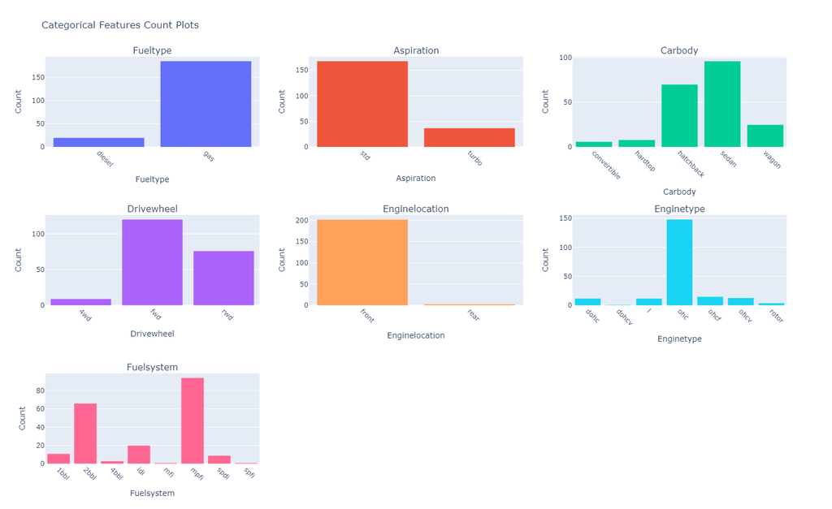

```python
import plotly.subplots as sp

categorical_columns = ['fueltype', 'aspiration', 'carbody', 'drivewheel',
                       'enginelocation', 'enginetype', 'fuelsystem']

df_cat = df.copy()
for c in categorical_columns:
    df_cat[c] = (df_cat[c].astype('string').str.strip().fillna('dl'))

fig = sp.make_subplots(rows=3, cols=3,
    subplot_titles=[col.capitalize() for col in categorical_columns])

row, col = 1, 1
for column in categorical_columns:
    vc = (df_cat[column]
          .value_counts(dropna=False)   # alle mitnehmen
          .sort_index())                # fixe Reihenfolge (oder sort_values())
    print(vc.index)
    cats = list(map(str, vc.index))     # Kategorien als Strings

    fig.add_trace(
        go.Bar(x=cats, y=vc.values, name=column),
        row=row, col=col
    )

    fig.update_xaxes(
        type='category',
        title_text=column.capitalize(),
        categoryorder="array",
        categoryarray=cats,
        tickangle=45,
        row=row, col=col
    )
    fig.update_yaxes(title_text="Count", row=row, col=col)

    col += 1
    if col > 3:
        col = 1
        row += 1

fig.update_layout(height=900, width=1300, showlegend=False,
                  title_text="Categorical Features Count Plots",
                  bargap=0.15)
fig.show()
```

ich habe kategorischen Variablen zunächst exploriert (Häufigkeiten, dominante Kategorien, seltene Kategorien) und anschließend überlegt, ob und wie man diese in numerische Faktoren übersetzen könnte.

**Die Logik:**

Dominante Kategorie = Basisfaktor 1.0

Weniger dominante Kategorie = etwas >1

Seltene oder fachlich teurere Kategorie = größerer Faktor

Teilweise fachlich begründet (z. B. Diesel teurer als Gas).

Das ist ein Mix aus fachlichem Wissen und heuristischer Gewichtung – allerdings ist das nicht die Standardmethode im Machine Learning (da nimmt man z. B. One-Hot-Encoding, Ordinal-Encoding oder Target-Encoding). Trotzdem finde ich sinnvoll, diesen Ansatz als Überlegung sauber zu dokumentieren.

Kategorien und Überlegung zur Faktorisierung

Bei der Analyse der kategorialen Merkmale fällt auf, dass manche Kategorien sehr dominant sind (z. B. Gas bei Fueltype, OHC bei Engine Type, Front bei Engine Location), während andere nur selten vorkommen. Für Machine Learning ist es jedoch erforderlich, diese Kategorien in numerische Werte umzuwandeln.

Eine Überlegung ist, Faktoren zu vergeben:

Dominante Kategorie → Basiswert 1.0

Weniger dominante, aber relevante Kategorie → Wert leicht über 1.0

Sehr seltene Kategorie → noch etwas größerer Faktor

Zusätzlich: fachliche Begründung (z. B. Diesel i. d. R. teurer als Benzin).

**Tabellarische Zusammenfassung:**

[output not shown]

Bewertung des Ansatzes

Dieser Ansatz liefert eine erste Annäherung an eine numerische Abbildung kategorialer Variablen.

Allerdings ist die Faktorisierung subjektiv und basiert auf einer Mischung aus fachlichem Wissen und Häufigkeit der Kategorien.

In der Praxis würden Datenanalysten eher Verfahren wie One-Hot-Encoding oder Target-Encoding verwenden, da diese Methoden objektiver und reproduzierbarer sind.

Meine Überlegung stellt einen spezifischen Ansatz dar und dient in erster Linie dazu, ein datenbasiertes, besseres Verständnis der Merkmale zu gewinnen. Es handelt sich dabei nicht um ein endgültiges Vorgehen für die Modellierung, sondern um eine gedankliche Stütze, wie man als Datenanalyst die Daten interpretieren und deren Einfluss einschätzen kann.

Für die eigentliche Modellierung werde ich weiterhin die etablierten Standardverfahren einsetzen.

### 2.1.7 Überblick über die Autohersteller:

Hier werden die Top-20 Autohersteller in der Daten dargestellt. z.B. Das Modell Peugeot 504 kommt 6-mal im Datensatz vor.

```python
import plotly.express as px
print("CarName",print(df['CarName'].unique()))
```

```
['alfa-romero giulia' 'alfa-romero stelvio' 'alfa-romero Quadrifoglio'
 'audi 100 ls' 'audi 100ls' 'audi fox' 'audi 5000' 'audi 4000'
 'audi 5000s (diesel)' 'bmw 320i' 'bmw x1' 'bmw x3' 'bmw z4' 'bmw x4'
 'bmw x5' 'chevrolet impala' 'chevrolet monte carlo' 'chevrolet vega 2300'
 'dodge rampage' 'dodge challenger se' 'dodge d200' 'dodge monaco (sw)'
 'dodge colt hardtop' 'dodge colt (sw)' 'dodge coronet custom'
 'dodge dart custom' 'dodge coronet custom (sw)' 'honda civic'
 'honda civic cvcc' 'honda accord cvcc' 'honda accord lx'
 'honda civic 1500 gl' 'honda accord' 'honda civic 1300' 'honda prelude'
 'honda civic (auto)' 'isuzu MU-X' 'isuzu D-Max ' 'isuzu D-Max V-Cross'
 'jaguar xj' 'jaguar xf' 'jaguar xk' 'maxda rx3' 'maxda glc deluxe'
 'mazda rx2 coupe' 'mazda rx-4' 'mazda glc deluxe' 'mazda 626' 'mazda glc'
 'mazda rx-7 gs' 'mazda glc 4' 'mazda glc custom l' 'mazda glc custom'
 'buick electra 225 custom' 'buick century luxus (sw)' 'buick century'
 'buick skyhawk' 'buick opel isuzu deluxe' 'buick skylark'
 'buick century special' 'buick regal sport coupe (turbo)'
 'mercury cougar' 'mitsubishi mirage' 'mitsubishi lancer'
 'mitsubishi outlander' 'mitsubishi g4' 'mitsubishi mirage g4'
 'mitsubishi montero' 'mitsubishi pajero' 'Nissan versa' 'nissan gt-r'
 'nissan rogue' 'nissan latio' 'nissan titan' 'nissan leaf' 'nissan juke'
 'nissan note' 'nissan clipper' 'nissan nv200' 'nissan dayz' 'nissan fuga'
 'nissan otti' 'nissan teana' 'nissan kicks' 'peugeot 504' 'peugeot 304'
 'peugeot 504 (sw)' 'peugeot 604sl' 'peugeot 505s turbo diesel'
 'plymouth fury iii' 'plymouth cricket' 'plymouth satellite custom (sw)'
 'plymouth fury gran sedan' 'plymouth valiant' 'plymouth duster'
 'porsche macan' 'porcshce panamera' 'porsche cayenne' 'porsche boxter'
 'renault 12tl' 'renault 5 gtl' 'saab 99e' 'saab 99le' 'saab 99gle'
 'subaru' 'subaru dl' 'subaru brz' 'subaru baja' 'subaru r1' 'subaru r2'
 'subaru trezia' 'subaru tribeca' 'toyota corona mark ii' 'toyota corona'
 'toyota corolla 1200' 'toyota corona hardtop' 'toyota corolla 1600 (sw)'
 'toyota carina' 'toyota mark ii' 'toyota corolla'
 'toyota corolla liftback' 'toyota celica gt liftback'
 'toyota corolla tercel' 'toyota corona liftback' 'toyota starlet'
 'toyota tercel' 'toyota cressida' 'toyota celica gt' 'toyouta tercel'
 'vokswagen rabbit' 'volkswagen 1131 deluxe sedan' 'volkswagen model 111'
 'volkswagen type 3' 'volkswagen 411 (sw)' 'volkswagen super beetle'
 'volkswagen dasher' 'vw dasher' 'vw rabbit' 'volkswagen rabbit'
 'volkswagen rabbit custom' 'volvo 145e (sw)' 'volvo 144ea' 'volvo 244dl'
 'volvo 245' 'volvo 264gl' 'volvo diesel' 'volvo 246']
CarName None
```

```
top_car_models:
 CarName
peugeot 504             6
toyota corolla          6
toyota corona           6
subaru dl               4
mitsubishi outlander    3
mazda 626               3
honda civic             3
mitsubishi mirage g4    3
mitsubishi g4           3
toyota mark ii          3
nissan clipper          2
honda civic cvcc        2
honda accord            2
mazda glc               2
mazda rx-7 gs           2
mazda glc deluxe        2
bmw x3                  2
bmw 320i                2
audi 100ls              2
volvo 264gl             2
Name: count, dtype: int64
<class 'pandas.core.series.Series'>
Index(['peugeot 504', 'toyota corolla', 'toyota corona', 'subaru dl',
       'mitsubishi outlander', 'mazda 626', 'honda civic',
       'mitsubishi mirage g4', 'mitsubishi g4', 'toyota mark ii',
       'nissan clipper', 'honda civic cvcc', 'honda accord', 'mazda glc',
       'mazda rx-7 gs', 'mazda glc deluxe', 'bmw x3', 'bmw 320i', 'audi 100ls',
       'volvo 264gl'],
      dtype='object', name='CarName')
```

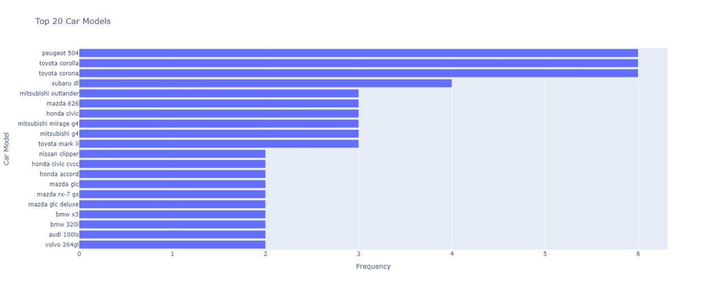

```python
import plotly.express as px

n = 20  # Number of top car models to plot
top_car_models = df['CarName'].value_counts().head(n) # A series, index sind 'Car Model'
print("top_car_models: \n", top_car_models)
print(type(top_car_models))
print( top_car_models.index)

# In ein DataFrame umwandeln
top_car_df = top_car_models.reset_index() # make  aDataFrame from a Series and CarName as column for frequency again:[ index, CarName]
top_car_df.columns = ['Car Model', 'Frequency'] # rename the colums [ index, CraName] to ['Car Model', 'Frequency']

# Plotly Express Barplot
fig = px.bar(
    top_car_df,
    x='Frequency',
    y='Car Model',
    orientation='h',  # horizontale Balken
    title=f'Top {n} Car Models'
)

fig.update_layout(
    xaxis_title="Frequency",
    yaxis_title="Car Model",
    yaxis=dict(autorange="reversed"),  # damit die häufigsten oben stehen
    height=600  # Höhe des Diagramms
)

fig.show()
```

### 2.1.8 Berechnung von Durchschnittpreis für Top-20 Autohersteller

Hier werden die teuersten Top-20 Autohersteller in der Daten dargestellt.

```
CarName
buick regal sport coupe (turbo)    45400.0
bmw x5                             41315.0
buick century special              40960.0
porsche boxter                     37028.0
jaguar xk                          36000.0
                                    ...
Nissan versa                        5499.0
mitsubishi mirage                   5389.0
toyota corona mark ii               5348.0
maxda rx3                           5195.0
chevrolet impala                    5151.0
Name: price, Length: 147, dtype: float64
```

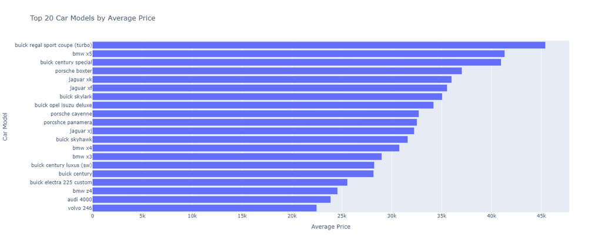

```python
import plotly.express as px

# Durchschnittspreise pro Modell berechnen
avg_prices_by_car = df.groupby('CarName')['price'].mean().sort_values(ascending=False)
print(avg_prices_by_car)
# Top N auswählen
n = 20
top_car_models = avg_prices_by_car.head(n)

# In DataFrame umwandeln
top_car_df = top_car_models.reset_index()
top_car_df.columns = ['Car Model', 'Average Price']

# Plot mit Plotly Express
fig = px.bar(
    top_car_df,
    x='Average Price',
    y='Car Model',
    orientation='h',
    title=f'Top {n} Car Models by Average Price'
)

# Layout anpassen
fig.update_layout(
    xaxis_title="Average Price",
    yaxis_title="Car Model",
    yaxis=dict(autorange="reversed"),  # Teuerste oben
    height=600
)

fig.show()
```

### 2.1.9 Durchschnittspreise der Hersteller im unteren Preissegment (günstigste 20 Autohersteller)

Hier werden die günstisten Top-20 Autohersteller in der Daten dargestellt.

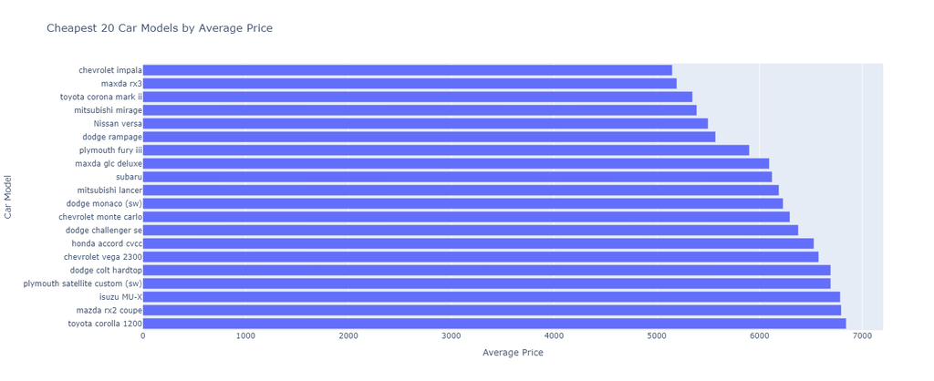

```python
import plotly.express as px

# Durchschnittspreise pro Modell berechnen, aufsteigend sortieren
avg_prices_by_car = df.groupby('CarName')['price'].mean().sort_values(ascending=True)

# Top N günstigste Modelle auswählen
n = 20
top_car_models = avg_prices_by_car.head(n)

# In DataFrame umwandeln
top_car_df = top_car_models.reset_index()
top_car_df.columns = ['Car Model', 'Average Price']

# Plotly Express Barplot
fig = px.bar(
    top_car_df,
    x='Average Price',
    y='Car Model',
    orientation='h',
    title=f'Cheapest {n} Car Models by Average Price'
)

# Layout anpassen
fig.update_layout(
    xaxis_title="Average Price",
    yaxis_title="Car Model",
    yaxis=dict(autorange="reversed"),  # damit das günstigste Auto unten steht
    height=600
)

fig.show()
```

### 2.1.10 Kategorische Merkmale vs. Preis: Boxplot

#### Der Boxplot ist ein zentrales Werkzeug in der Datenanalyse. Er visualisiert die Verteilung von Daten und macht wichtige Eigenschaften wie Lage, Streuung und mögliche Ausreißer auf einen Blick erkennbar.

#### 2.1.10.1 Interquartile Range (IQR)**

Der Interquartilbereich (IQR) beschreibt die Spannweite der mittleren 50 % der Daten.

Q1 (25. Perzentil): Wert, unter dem 25 % der Daten liegen.

Q2 (Median, 50. Perzentil): Wert, unter dem 50 % der Daten liegen.

Q3 (75. Perzentil): Wert, unter dem 75 % der Daten liegen.

Formel für IQR:

IQR=Q3−Q1

Der IQR gibt also die Spannweite des „mittleren Blocks“ der Daten an – er ignoriert die extremen Ausreißer.

Beispiel: Wenn Q1 = 10 und Q3 = 20 → IQR = 20 − 10 = 10.

#### 2.1.10.2 Whiskers (typisch 1.5×IQR)**

Die Whiskers in einem Boxplot zeigen die Daten „außerhalb“ des mittleren Bereichs, aber ohne Ausreißer.

Standardregel:

Unteres Whisker-Limit: Q1−1.5×IQR

Oberes Whisker-Limit: Q3+1.5×IQR

Alles unterhalb von Q1 − 1.5×IQR oder oberhalb von Q3 + 1.5×IQR wird als Ausreißer markiert (oft Punkte außerhalb des Whiskers).

Beispiel:

Q1 = 10, Q3 = 20 → IQR = 10

Unteres Limit: 10 − 1.5×10 = −5

Oberes Limit: 20 + 1.5×10 = 35

Wenn deine Daten von 0 bis 40 reichen:

Whisker zeigen nur 0 bis 35

Werte >35 (z. B. 37, 40) sind Ausreißer.

#### 2.1.10.3. Visualisierung im Boxplot

```
      ┌─────────────┐  ← Q3 (75%)
      │             │
      │    Box      │  ← mittlere 50% (Q1–Q3)
      │             │
      └─────────────┘  ← Q1 (25%)
    Whisker:   │
               │
               └── Punkte = Ausreißer (>1.5×IQR)
```

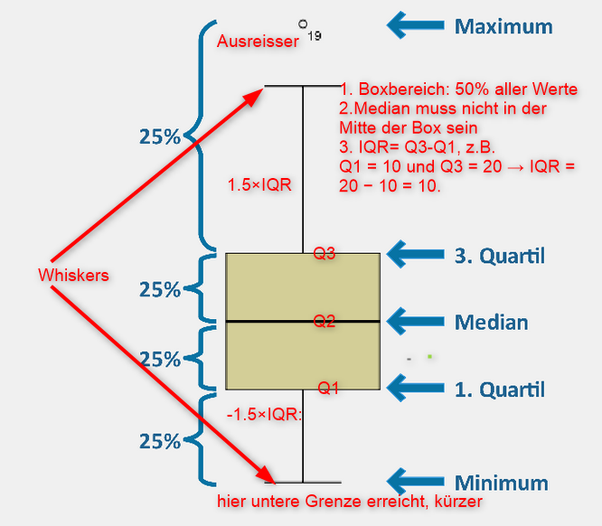

#### Zusammenhang zwischen Whisker und 3-facher Standardabweichung

Da das Thema **Ausreißererkennung** hier behandelt wird, ist es sinnvoll einen Vergeleich der zwei Methoden zur **Ausreißererkennung** zu machen

#### 1. Whisker (Boxplot) – IQR-Methode

- **IQR** = Interquartilsabstand = Q3 − Q1
- **Unteres Whisker-Limit**: `Q1 - 1.5 × IQR`
- **Oberes Whisker-Limit**: `Q3 + 1.5 × IQR`

**Eigenschaften:**

- Robust gegenüber Ausreißern, da nur die mittleren 50 % der Daten betrachtet werden. Das bedeutet dass Ausreißer keinen Einfluß auf IQR haben.
- Funktioniert auch bei schiefen oder nicht-normalverteilten Daten gut.

#### 2️. 3-fache Standardabweichung – Z-Score-Methode

- **Mittelwert**: μ
- **Standardabweichung**: σ
- **Unteres Limit**: `μ - 3σ`
- **Oberes Limit**: `μ + 3σ`

**Eigenschaften:**

- Annahme: Daten sind **normalverteilt**.
- Laut 68–95–99.7-Regel liegen ~99.7 % der Werte innerhalb von ±3σ.
- Ausreißer sind Werte >3σ vom Mittelwert entfernt.

#### 3️. Vergleich / Zusammenhang

| Aspekt | IQR (Whisker) | 3σ-Methode |
| --- | --- | --- |
| Basis | Quartile (Q1, Q3) | Mittelwert & Standardabweichung |
| Robustheit | Sehr robust gegenüber Ausreißern | Weniger robust, Ausreißer beeinflussen σ |
| Verteilung | Keine Annahmen | Annahme: Normalverteilung |
| Typische Erkennung | Werte >1.5×IQR vom Quartil entfernt | Werte >3σ vom Mittelwert entfernt |
| Sensitivität | erkennen auch Moderate Ausreißer | erkennen nur Extreme Ausreißer bei Normalverteilung |

Beispiel:

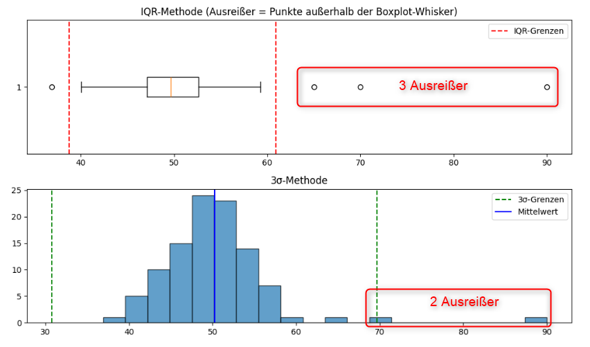

Hier sieht man den Vergleich zwischen IQR-Methode und 3σ-Methode:

IQR-Grenzen: ca. 38.8 bis 61.0

3σ-Grenzen: ca. 30.8 bis 69.7

**Interpretation:**

Die IQR-Methode ist enger → erkennt moderate Ausreißer wie den Wert 65 bereits.

**Das zeigt den Unterschied in der Sensitivität:**

IQR = empfindlicher, moderate Abweichungen gelten schon als Ausreißer.

3σ = „toleranter“, nur extreme Abweichungen zählen.

**Vergleich: Ausreißer-Erkennung mit IQR vs. 3σ**

| Wert | IQR-Methode (1.5×IQR) | 3σ-Methode |
| --- | --- | --- |
| 65 | ✅ Ausreißer | ❌ kein Ausreißer |
| 70 | ✅ Ausreißer | ✅ Ausreißer |
| 90 | ✅ Ausreißer | ✅ Ausreißer |

**Fazit:**

- Beide Methoden erkennen Ausreißer, aber **Whisker basiert auf der mittleren Hälfte der Daten** und ist robuster bei Schiefe oder Extremwerten.
- Die **3σ-Regel** eignet sich besonders für normalverteilte Daten.
- Bei symmetrischer, ungefähr normalverteilter Datenmenge sind die Grenzen oft ähnlich, aber nicht identisch.

### Python Code für Vergleich und Zusammenhang zwischen IQR und Standardabweichung:

```
lower_bound_iqr 38.772358092628934
upper_bound_iqr 60.95989505121992
lower_bound_sigma 30.77253282384397
upper_bound_sigma 69.67555924029105
```

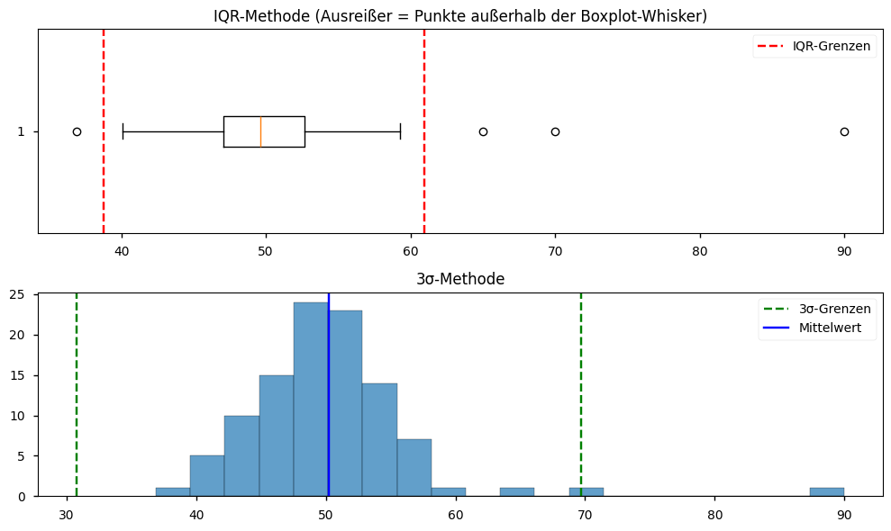

```
(np.float64(38.772358092628934),
 np.float64(60.95989505121992),
 np.float64(30.77253282384397),
 np.float64(69.67555924029105))
```

```python
# Test Beispiel: Python Code für Vergleich / Zusammenhang zwischen IQR und Standardabweichung:
import numpy as np
import pandas as pd
import matplotlib.pyplot as plt

# Zufällige Daten mit Normalverteilung
np.random.seed(42)
data = np.random.normal(loc=50, scale=5, size=100)

# Einige Ausreißer hinzufügen (moderate und extreme)
data = np.append(data, [65, 70, 90])

# In DataFrame packen
df_test = pd.DataFrame(data, columns=["Werte"])

# IQR-Berechnung
Q1 = df_test["Werte"].quantile(0.25)
Q3 = df_test["Werte"].quantile(0.75)
IQR = Q3 - Q1
lower_bound_iqr = Q1 - 1.5 * IQR
upper_bound_iqr = Q3 + 1.5 * IQR

print("lower_bound_iqr", lower_bound_iqr)
print("upper_bound_iqr", upper_bound_iqr)

# 3σ-Berechnung
mean = df_test["Werte"].mean()
std = df_test["Werte"].std()
lower_bound_sigma = mean - 3 * std
upper_bound_sigma = mean + 3 * std

print("lower_bound_sigma", lower_bound_sigma)
print("upper_bound_sigma", upper_bound_sigma)

# Plot erstellen
plt.figure(figsize=(10,6))

# Boxplot für IQR
plt.subplot(2,1,1)
plt.boxplot(df_test["Werte"], vert=False)
plt.axvline(lower_bound_iqr, color="red", linestyle="--", label="IQR-Grenzen")
plt.axvline(upper_bound_iqr, color="red", linestyle="--")
plt.title("IQR-Methode (Ausreißer = Punkte außerhalb der Boxplot-Whisker)")
plt.legend()

# Histogramm mit 3σ
plt.subplot(2,1,2)
plt.hist(df_test["Werte"], bins=20, alpha=0.7, edgecolor="black")
plt.axvline(lower_bound_sigma, color="green", linestyle="--", label="3σ-Grenzen")
plt.axvline(upper_bound_sigma, color="green", linestyle="--")
plt.axvline(mean, color="blue", linestyle="-", label="Mittelwert")
plt.title("3σ-Methode")
plt.legend()

plt.tight_layout()
plt.show()

(lower_bound_iqr, upper_bound_iqr, lower_bound_sigma, upper_bound_sigma)
```

#### 4. Intepretation der Ergebnisse vom Boxplot:

**4.1 fueltype vs. Price**

Gas ist der häufigste Treibstofftyp. Die Preise liegen meist zwischen 6.000 – 20.000 $,

mit Ausreißern bis über 30.000 $.

Diesel-Autos scheinen im Median etwas teurer als Gas-Autos, aber die Stichprobe ist kleiner.

👉 Interpretation: Dieselkraftstoff korreliert mit tendenziell höheren Preisen.

**4.2 aspiration vs. Price**

Standard-Aspiration (std: Luftzufuhr ohne Turbo oder Kompressor) hat eine breite Preisverteilung, Median im mittleren Bereich.

Turbo-Autos sind im Median teurer.

👉 Interpretation: Turbo-Autos könnten ein Premium-Segment darstellen.

**4.3 carbody vs. Price**

Sedan und Hatchback dominieren und liegen im mittleren bis unteren Preisbereich.

Convertible (Cabrio) und Hardtop zeigen höhere Medianpreise und größere Varianz.

👉 Interpretation: Die Karosserieform hat deutlichen Einfluss auf den Preis, Premium-Karosserien (Cabrio, Hardtop) → teurer.

**4.4. drivewheel vs. Price**

RWD (Heckantrieb) → tendenziell teurere Autos, größerer Median.

FWD (Frontantrieb) → günstigere Autos, am häufigsten vertreten.

4WD (Allrad) → wenige Datenpunkte, Median im mittleren Bereich.

👉 Interpretation: Heckantrieb wird eher bei teuren Autos verwendet (Sportwagen/Luxusautos).

**4.5 enginelocation vs. Price**

Front → fast alle Autos, Preise meist unter 20.000 $.

Rear (Heckmotor) → sehr wenige Autos, aber deutlich höherer Preisbereich.

👉 Interpretation: Heckmotor ist selten, typisch für Sportwagen, deutlich teurer.

**4.6 enginetype vs. Price**

ohc (Overhead Camshaft) → am häufigsten, Preise im unteren bis mittleren Bereich.

👉 Interpretation: Bestimmte Motortypen (z. B. dohc, rotor) sind mit Premiumautos assoziiert.

**4.7 fuelsystem vs. Price**

idi und spdi → sehr kleine Gruppen, mit hohen Ausreißern.

```
['fueltype', 'aspiration', 'carbody', 'drivewheel', 'enginelocation', 'enginetype', 'fuelsystem']
```

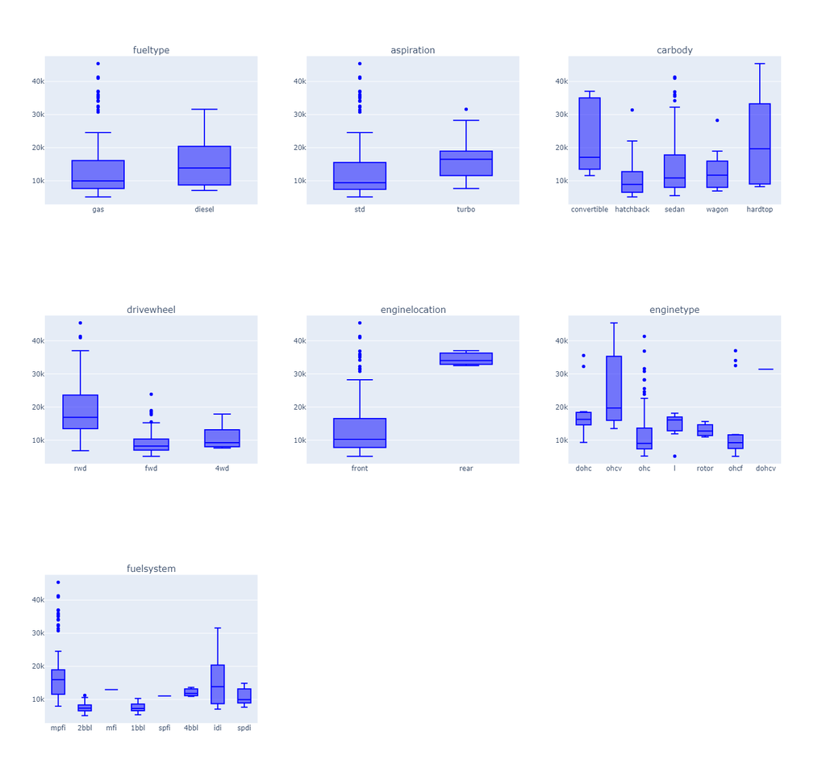

```python
# code für Boyplot: Price vs. Kategorie:

import plotly.graph_objects as go
from plotly.subplots import make_subplots
from math import ceil

# Categorical Feature vs. Price
print(categorical_columns)
n_cols = 3
n_rows = ceil(len(categorical_columns) / n_cols)

fig = make_subplots(rows=n_rows, cols=n_cols, subplot_titles=categorical_columns)

for idx, feature in enumerate(categorical_columns):
    row = idx // n_cols + 1
    col = idx % n_cols + 1

    # Einzelner Boxplot mit plotly.express erzeugen
    box_fig = px.box(df, x=feature, y='price', points='outliers', color_discrete_sequence=["blue"])

    # Traces in die Subplots einfügen
    for trace in box_fig.data:
        fig.add_trace(trace, row=row, col=col)

fig.update_layout(height=450 * n_rows, width=500 * n_cols, showlegend=False)
fig.show()
```

## Boxplots für nunmerische Spalten: Ausreisser erkennen

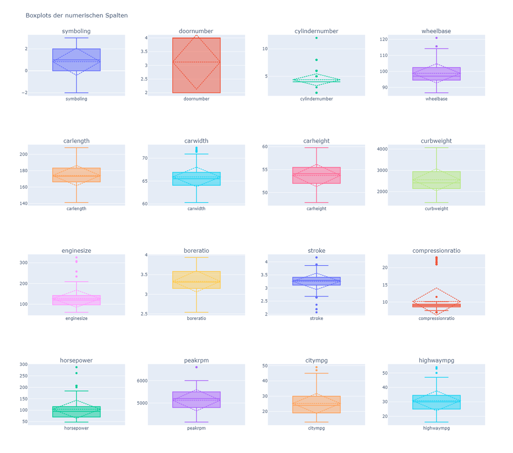

```python
import plotly.express as px
import plotly.subplots as sp
import plotly.graph_objects as go

# Angenommen dein DataFrame heißt df
numerical_columns = ['symboling','doornumber','cylindernumber','wheelbase', 'carlength',
                     'carwidth', 'carheight', 'curbweight','enginesize', 'boreratio',
                     'stroke', 'compressionratio', 'horsepower','peakrpm', 'citympg', 'highwaympg']

# Anzahl Spalten für das Layout (z. B. 4 pro Zeile)
cols = 4
rows = -(-len(numerical_columns) // cols)  # Rundung nach oben

# Subplot-Layout vorbereiten
fig = sp.make_subplots(rows=rows, cols=cols, subplot_titles=numerical_columns)

# Jede numerische Spalte als Boxplot hinzufügen
for i, col in enumerate(numerical_columns):
    r = i // cols + 1
    c = i % cols + 1

    fig.add_trace(
        go.Box(y=df[col], name=col, boxmean='sd'),  # boxmean='sd' zeigt auch Mittelwert + Std
        row=r, col=c
    )

# Layout schöner machen
fig.update_layout(height=1300, width=1400, showlegend=False, title_text="Boxplots der numerischen Spalten")
fig.show()
```

### 2.1.11 Numerische Werte mit Bar-Darstellung

Normalerweise werden numerische Werte mit einem Histogramm dargestellt, da dies die Verteilung der Werte zeigt. In diesem Fall werden sie jedoch mit einem Balkendiagramm (Barplot) abgebildet, um gezielt die Anzahl der Messwerte in bestimmten Kategorien oder Bereichen hervorzuheben und mehr Details sichtbar zu machen.

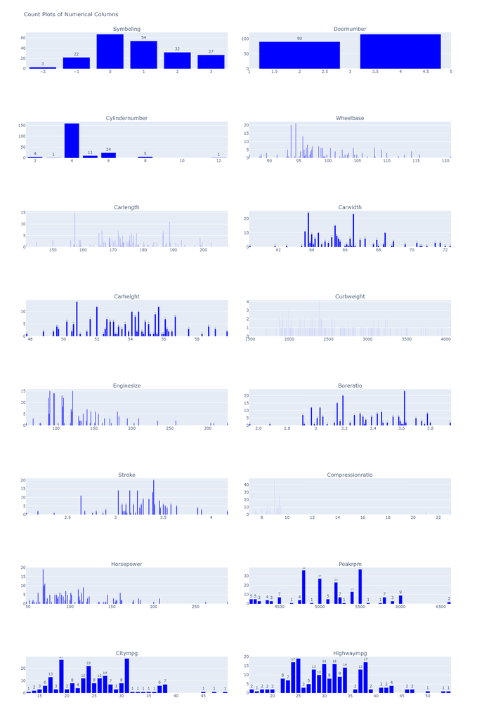

```python
# jeder Werte zeigen, ähnlich wie histogramm (Werte aber zusammenfasst)

numerical_columns = ['symboling','doornumber','cylindernumber','wheelbase', 'carlength', 'carwidth', 'carheight', 'curbweight',
                     'enginesize', 'boreratio', 'stroke', 'compressionratio', 'horsepower',
                     'peakrpm', 'citympg', 'highwaympg']

single_color = 'blue'  # eine Farbe für alle Plots

fig = make_subplots(
    rows=8, cols=2,
    subplot_titles=[col.capitalize() for col in numerical_columns],
    horizontal_spacing=0.05,  # engerer horizontaler Abstand
    vertical_spacing=0.08
)

row, col = 1, 1
for col_name in numerical_columns:
    counts = df[col_name].value_counts().reset_index()
    counts.columns = [col_name, 'Count']

    fig.add_trace(
        go.Bar(
            x=counts[col_name],
            y=counts['Count'],
            text=counts['Count'],
            textposition='outside',
            marker_color=single_color

        ),
        row=row, col=col
    )

    col += 1
    if col > 2:  # nur 2 Spalten
        col = 1
        row += 1

fig.update_layout(
    height=2200, width=1600,  # Höhe und Breite anpassen
    title_text="Count Plots of Numerical Columns",
    showlegend=False
)

fig.show()
```

## 2.2 Explorative Datenanalyse (EDA)

Explorative Datenanalyse (EDA) ist ein methodischer Ansatz zur ersten Untersuchung von Datensätzen ohne vorgegebene Hypothesen. Ziel ist es, durch statistische und visuelle Methoden Muster, Zusammenhänge, Ausreißer und Datenstrukturen zu erkennen. Dabei hilft EDA, ein besseres Verständnis der Daten zu erlangen, Hypothesen zu generieren und die Datenqualität zu überprüfen.

EDA verwendet häufig Streudiagramme und Korrelationsanalysen, um Zusammenhänge zwischen Variablen zu untersuchen, während die deskriptive Statistik eher einfache Zusammenfassungen und Standardvisualisierungen liefert.

### 2.2.1 Streudiagramm: Preis (y-Achse) vs. numerische Spalte (x-Achse)

Ein Streudiagramm ist für die explorative Datenanalyse (EDA) sehr nützlich, weil es:

- Zusammenhänge zwischen zwei numerischen Variablen sichtbar macht
- Zeigt, ob eine positive, negative oder keine Korrelation vorliegt
- Hilfreich ist, um Muster, Trends oder Ausreißer zu erkennen
- Visuell sofort Einblicke in die Datenstruktur und mögliche Abhängigkeiten gibt

**Kurz:**  
Ein Streudiagramm unterstützt in der EDA dabei, Beziehungen in den Daten zu verstehen und auf Basis dieser Erkenntnisse weitere Analyseschritte zu planen.

### Interpretation der Scatterplots (Features vs. Preis)

#### 1. Abmessungen

- **carlength vs price:**  
  Längere Autos → tendenziell teurer. Positiver Zusammenhang, aber mit Streuung.
- **carwidth vs price:**  
  Breitere Autos → deutlich teurer. Klarer linearer Trend.
- **carheight vs price:**  
  Kein klarer Trend. Manche hohe Autos sind teuer, andere nicht → schwacher Zusammenhang.
- **wheelbase vs price:**  
  Längere Radstände → etwas teurer, aber viele Ausreißer. Mittlerer Zusammenhang.

#### 3. Motorcharakteristik

- **stroke vs price:**  
  Kaum Zusammenhang, stark verstreute Werte.
- **compressionratio vs price:**  
  Kein klarer linearer Trend. Einzelne Autos mit hoher Kompression → teurer, aber unregelmäßig.
- **horsepower vs price:**  
  Sehr deutlicher positiver Zusammenhang. Leistungsstärkere Autos kosten klar mehr. Einer der stärksten Prädiktoren.
- **peakrpm vs price:**  
  Kein klarer Trend, Daten stark verstreut. Schwacher Prädiktor.

#### 4. Verbrauchswerte

- **citympg vs price:**  
  Negativer Zusammenhang: sparsame Autos (hoher mpg) sind günstiger.
- **highwaympg vs price:**  
  Ähnlich wie citympg: höhere Effizienz → niedrigere Preise. Moderater negativer Zusammenhang.

#### 5. Karosserie & Türen

- **doornumber vs price:**  
  Kein klarer Unterschied zwischen 2- und 4-Türern. Schwacher Einfluss auf den Preis.

#### Gesamtbewertung

- **Sehr starke Prädiktoren (hohe Aussagekraft):**  
  `enginesize`, `curbweight`, `horsepower`, `cylindernumber`, `carwidth`, `carlength`.
- **Mittlere Prädiktoren:**  
  `wheelbase`, `boreratio`, `citympg`, `highwaympg`.
- **Schwache/kaum relevante Prädiktoren:**  
  `carheight`, `stroke`, `compressionratio`, `peakrpm`, `doornumber`.

```
['doornumber', 'cylindernumber', 'wheelbase', 'carlength', 'carwidth', 'carheight', 'curbweight', 'enginesize', 'boreratio', 'stroke', 'compressionratio', 'horsepower', 'peakrpm', 'citympg', 'highwaympg']
```

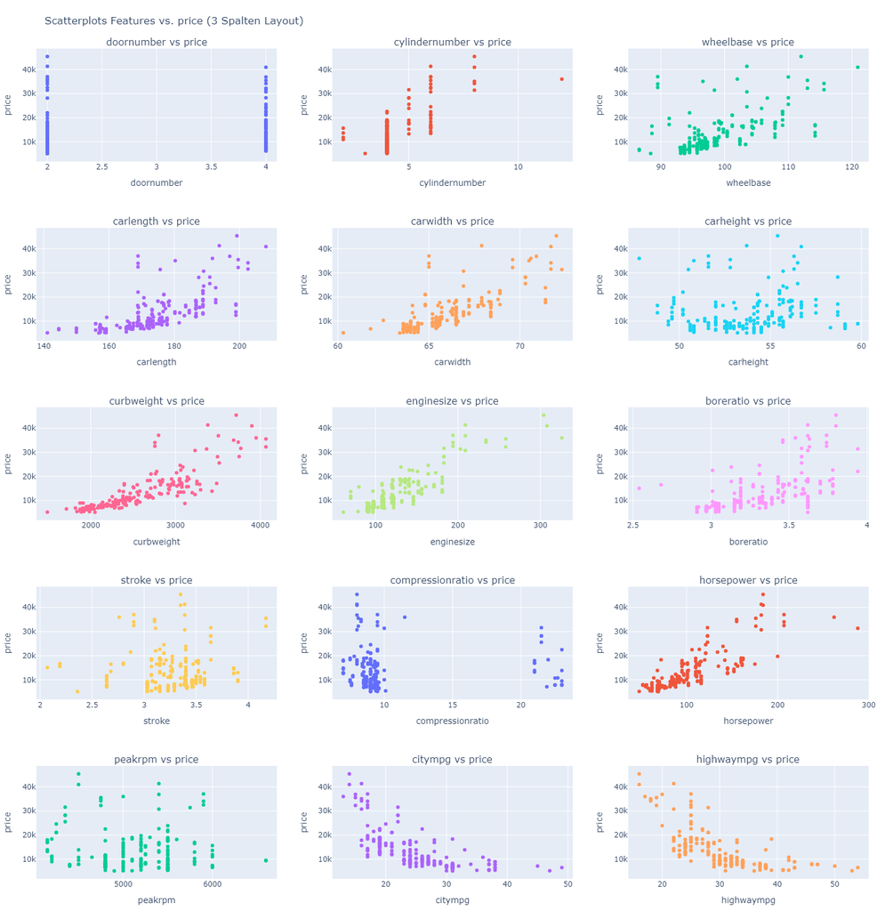

```python
# Feuture engineering for numerical_columns: Scatter plot

numerical_columns = ['doornumber','cylindernumber','wheelbase', 'carlength', 'carwidth', 'carheight', 'curbweight',
                     'enginesize', 'boreratio', 'stroke', 'compressionratio', 'horsepower',
                     'peakrpm', 'citympg', 'highwaympg']

target = 'price'
# Annahme: df ist dein DataFrame und features_for_scatter deine Liste der Features
# Beispielhafte Berechnung der Achsenbereiche, wie zuvor bestimmt (hier musst du ggf. deine realen Daten nutzen)
features_for_scatter = [f for f in numerical_columns if f != target]
print(features_for_scatter)
feature_ranges = {
    feature: (df[feature].min(), df[feature].max()) for feature in features_for_scatter
}

# Subplot-Layout mit 3 Spalten und entsprechender Zeilenanzahl
num_features = len(features_for_scatter)
num_cols = 3
num_rows = (num_features + num_cols - 1) // num_cols

fig = make_subplots(
    rows=num_rows, cols=num_cols,
    subplot_titles=[f"{feat} vs {target}" for feat in features_for_scatter],
    vertical_spacing=0.08  # Weniger Abstand zwischen den Reihen
)

#fig = make_subplots(rows=num_rows, cols=num_cols,subplot_titles=[f"{feat} vs {target}" for feat in features_for_scatter])

for i, feature in enumerate(features_for_scatter):
    row = i // num_cols + 1
    col = i % num_cols + 1
    # 5% Padding links und rechts für x-Achse
    x_min, x_max = feature_ranges[feature]
    x_range_pad = (x_max - x_min) * 0.05
    x_axis_range = [x_min - x_range_pad, x_max + x_range_pad]

    scatter = go.Scatter(x=df[feature], y=df[target], mode='markers', name=feature)
    fig.add_trace(scatter, row=row, col=col)

    # Setze die x-Achse des Subplots mit Range und angemessener Tick-Anzahl
    fig.update_xaxes(range=x_axis_range, row=row, col=col, nticks=5)

    # Label für jede Achse hinzufügen (optional)
    fig.update_xaxes(title_text=feature, row=row, col=col)
    fig.update_yaxes(title_text=target, row=row, col=col)

# Layout anpassen: Grösse, Abstand, Titel
fig.update_layout(height=300*num_rows, width=1300,  # statt 1000 jetzt 1200 für +20%
                  title_text="Scatterplots Features vs. price (3 Spalten Layout)",
                  showlegend=False,
                  margin=dict(l=40, r=40, t=80, b=40))


fig.show()
```

### 2.2.2 Korrelationskarte (Heatmap)

### 1. Correlation Map of `numerical_columns`

Eine **Korrelationskarte (Heatmap)** zeigt die **Zusammenhänge zwischen allen numerischen Spalten** in einer Matrixform.

- Jede Zelle enthält den **Korrelationskoeffizienten** (z. B. Pearson), der angibt, wie stark zwei Variablen linear miteinander zusammenhängen (Werte zwischen **-1 und +1**).
- **Positive Werte** → beide Variablen steigen oder fallen gemeinsam.
- **Negative Werte** → wenn eine steigt, sinkt die andere.
- **Werte nahe 0** → kein linearer Zusammenhang.

### 2. Warum ist das gut?

- Erkennt **starke Prädiktoren** für die Zielvariable (z. B. `price`).
- Hilft, **Multikollinearität** zu identifizieren (z. B. `curbweight` und `enginesize` könnten stark korrelieren).
- Unterstützt bei der **Feature Selection**, um redundante Variablen zu vermeiden.
- Liefert eine schnelle **visuelle Übersicht**, welche numerischen Features wichtig sein könnten.

df.corr(method="pearson") # Standard, lineare Korrelation

df.corr(method="kendall") # Rangkorrelation (Monotonie)

df.corr(method="spearman") # Rangkorrelation (monoton, robuster gegen Ausreißer)

```
Pearson → misst linearen Zusammenhang

Spearman → misst monotonen Zusammenhang (nicht unbedingt linear, basiert auf Rängen)

Kendall → ähnlich wie Spearman, aber anders gewichtet
```

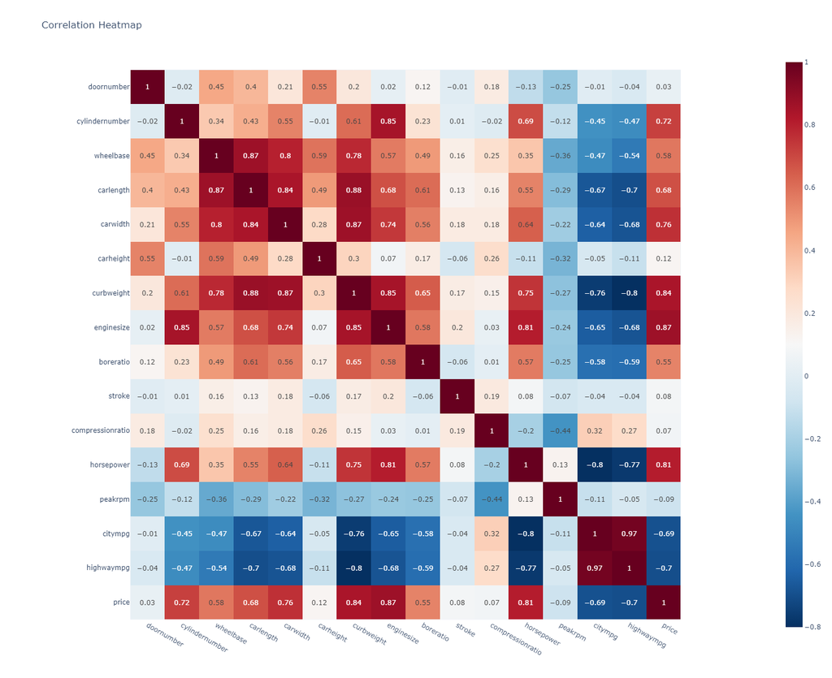

```python
# correlation map for numerical_columns:
numerical_columns1 = ['doornumber','cylindernumber','wheelbase', 'carlength', 'carwidth', 'carheight', 'curbweight',
                     'enginesize', 'boreratio', 'stroke', 'compressionratio', 'horsepower',
                     'peakrpm', 'citympg', 'highwaympg','price']

correlation_matrix = df[numerical_columns1].corr().round(2) #Pearson-Korrelation
# Heatmap mit Plotly Express
fig = px.imshow(
    correlation_matrix,
    text_auto=True,         # Werte direkt in die Zellen schreiben
    color_continuous_scale='RdBu_r',  # entspricht 'coolwarm'
    title="Correlation Heatmap"
)
fig.update_layout(width=1200, height=1200)
fig.show()
```

### 3. Korrelation der Features mit dem Fahrzeugpreis

[output not shown]

### 4. Analyse der Korrelationen mit dem Fahrzeugpreis

Die Analyse der Merkmale zeigt, dass bestimmte Fahrzeugparameter stark mit dem Fahrzeugpreis korrelieren:

- **Starke positive Korrelation:**
  - Motorgröße (**enginesize**)
  - Leergewicht (**curbweight**)
  - PS (**horsepower**)  
    Fahrzeuge mit größeren Motoren, höherem Gewicht und mehr Leistung tendieren dazu, teurer zu sein.
- **Weitere positive Einflüsse:**
  - Fahrzeugbreite (**carwidth**)
  - Zylinderanzahl (**cylindernumber**)
  - Fahrzeuglänge (**carlength**)
  - Radstand (**wheelbase**)
  - Bohrungsverhältnis (**boreratio**)  
    Diese Merkmale tragen ebenfalls positiv zum Preis bei, wenn auch moderater.
- **Negative Korrelation:**
  - Verbrauch auf der Autobahn (**highwaympg**)
  - Verbrauch in der Stadt (**citympg**)  
    Autos mit besserer Kraftstoffeffizienz sind tendenziell günstiger.
- **Geringe oder kaum relevante Korrelation:**
  - Fahrzeughöhe (**carheight**)
  - Maximale Drehzahl (**peakrpm**)
  - Hub (**stroke**)
  - Verdichtungsverhältnis (**compressionratio**)
  - Anzahl der Türen (**doornumber**)  
    Diese Merkmale haben nur einen schwachen Einfluss auf den Preis.

> **Fazit:**  
> Motorgröße, Leergewicht und PS sind die stärksten positiven Indikatoren für den Fahrzeugpreis. Fahrzeugbreite und Zylinderanzahl sind ebenfalls wichtig. Die Kraftstoffeffizienz (highwaympg, citympg) wirkt stark negativ auf den Preis. Ähnlich wie im Streudiagramm spiegeln die Korrelationswerte die gleichen Zusammenhänge wider.

**Mit dieser Erkenntnis lässt sich folgende Frage des Unternehmens gut beantworten:**

**Das Unternehmen möchte wissen:**

1. Welche Variablen sind signifikant für die Vorhersage des Autopreises?
2. Wie gut erklären diese Variablen den Preis eines Autos?

# 3. Data Preparation (Datenaufbereitung)

Für Machine-Learning ist sehr wichtig, eine gute aufbereitete Daten zu haben, um ein allgemein aussagkräftiges Modell zu tranineren.

## 3.1. Datenbereinigung

- car_ID: eine laufende Nummer, keine Bedeutung für Datenanalyse und maschinelles Lernen. Löschen
- citympg und hightwaympg: die Verteilung wird noch mal genau angeschaut. Die Aussereisser werden bereinigt. siehe **Punkt 3.5**

## 3.2. Umwandlung von kategorischen Daten in numerischen Daten

Anzahl von Türen und Zylindern sind als kategorische Daten dargestellt. sie werden in Zahlen umgewandelt(schon erledigt in der Deskriptiven Analyse)

## 3.3. Zerlegung von kategorischen Daten in zwei Spalten: brand und model

In der Spalte 'CarName' sind Information über Marke und Modelle zusammengefasst. Sie sollen in zwei Spalten dargestellt werden

## 3.4. Anwendung von log(y),sqrt(y), x^2 usw. auf bestimmten Spalten: x: Preis, y: Werte in der Spalten

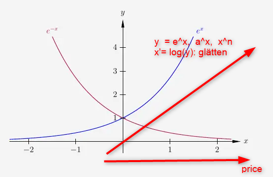

1. was bedeutet das z.B. log() Transformation: wenn y Werte (Enginesize) eine ideale Funktion von y= e^x, x(Preis), dannn log(y) wird dann linear zu x(Preis)
2. Logarithmen helfen, schiefe (skewed) Verteilungen oder extrem große Wertebereiche, besser für Modelle zu optimieren.
3. Das geiche gilt für andere funktionale Beziehung wie sqrt() usw.

## 3.5. Analyse von Ausreißern in citympg und highwaympg

### 3.5.1 Statistische Betrachtung:

1. Was ist die Standardabweichung (σ oder std)?
- Die Standardabweichung misst, wie stark die einzelnen Werte einer Datenmenge im Durchschnitt von deren Mittelwert (Durchschnitt) abweichen.
- Kleine Standardabweichung → die Werte liegen eng um den Mittelwert herum (geringe Streuung).
- Große Standardabweichung → die Werte sind weit vom Mittelwert verteilt (hohe Streuung).

Formel (für eine Stichprobe):

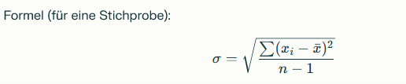

wobei xi = einzelner Wert, xˉ = Mittelwert, n = Anzahl der Werte.

2. Was bedeutet „3-fache Standardabweichung“? Wenn die Daten annähernd normalverteilt (Glockenkurve) sind, gilt die sogenannte 68–95–99,7-Regel:
- ±1 σ → ca. 68% aller Werte liegen innerhalb einer Standardabweichung vom Mittelwert.
- ±2 σ → ca. 95% aller Werte liegen innerhalb von zwei Standardabweichungen.
- ±3 σ → ca. 99,7% aller Werte liegen innerhalb von drei Standardabweichungen.
3. Das heißt: die Werte außer ±3σ werden beseitigt. Werte, die mehr als 3 Standardabweichungen vom Mittelwert entfernt sind, treten sehr selten auf (~0,3% Wahrscheinlichkeit). In der Statistik werden diese oft als Ausreißer betrachtet.

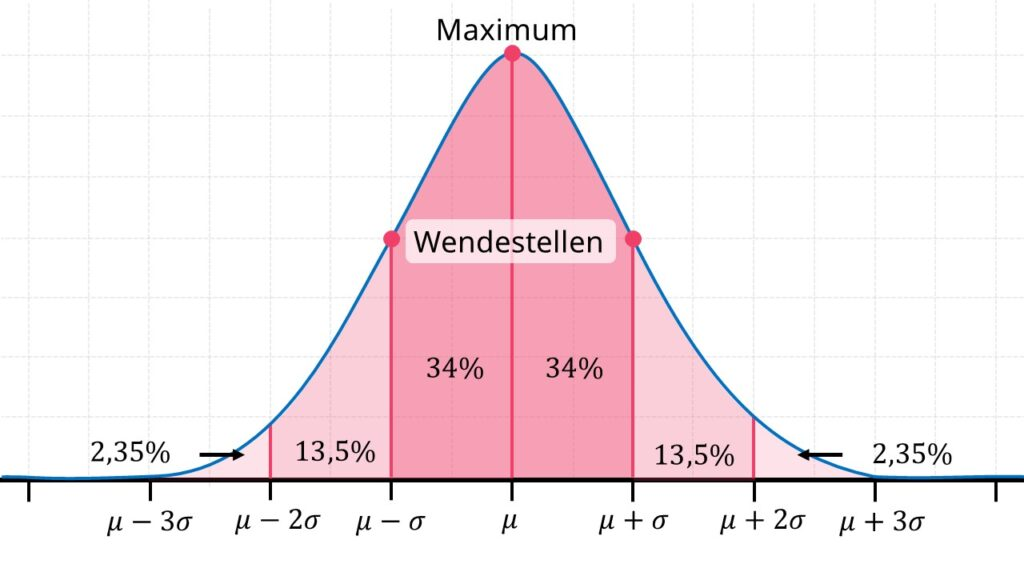

```python
#sns.pairplot(df)
```

### 3.5.2 Analyse von citympg und highwaympg:

```
-- statistische Werte von highwaympg --
min.: 16
max.: 54
mean: 30.75121951219512
median: 30.0
std: 6.886443130941824
6*std: 20.659329392825473
```

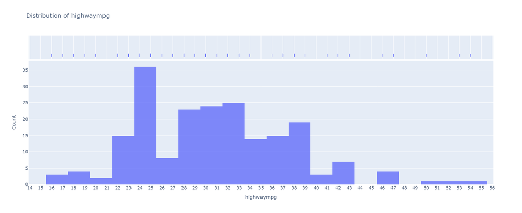

```
-- statistische Werte von citympg --
min.: 13
max.: 49
mean: 25.21951219512195
median: 24.0
std: 6.542141653001622
6*std: 19.626424959004865
```

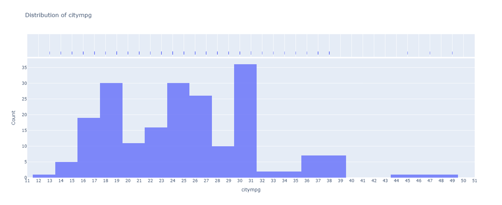

```python
# # Analyse von citympg und highwaympg:

print("-- statistische Werte von highwaympg --")

print("min.:", df['highwaympg'].min())
print("max.:",df['highwaympg'].max())
print("mean:",df['highwaympg'].mean())
print("median:",df['highwaympg'].median())
print("std:",df['highwaympg'].std())
print("6*std:",3*df['highwaympg'].std())

fig = px.histogram(df, x='highwaympg', nbins=30, marginal="rug", title='Distribution of highwaympg', opacity=0.8)

fig.update_layout(
    xaxis_title='highwaympg',
    yaxis_title='Count',
    height=600  # Höhe des Plots
)

fig.update_xaxes(
    tickmode='linear',
    tick0=0,
    dtick=1  # Tick-Beschriftungen alle 2 Einheiten
)
fig.show()

print("-- statistische Werte von citympg --")

print("min.:", df['citympg'].min())
print("max.:",df['citympg'].max())
print("mean:",df['citympg'].mean())
print("median:",df['citympg'].median())
print("std:",df['citympg'].std())
print("6*std:",3*df['citympg'].std())

fig = px.histogram(df, x='citympg', nbins=30, marginal="rug", title='Distribution of citympg', opacity=0.8)

fig.update_layout(
    xaxis_title='citympg',
    yaxis_title='Count',
    height=600  # Höhe des Plots
)

fig.update_xaxes(
    tickmode='linear',
    tick0=0,
    dtick=1  # Tick-Beschriftungen alle 2 Einheiten
)
fig.show()
```

### 3.5.3 Löschbedingung von Ausreißern: Spalte:'highwaympg'

### mean: 30.75121951219512

### std: 6.886443130941824

### limit_right: mean+3*std=30.75+3 x 6.88(20.64)= ca. 52; Werte > 52 werden gelöscht: nur zwei Werte 53, 54 betroffen

### limit_left: mean-+3*std= 30.75-3 x 6.88(20.64)= ca. 10; Werte < 10 werden gelöscht: keine Werte betroffen

```python
# werden später beim Modelltraining benutzt
limit_highwaympg_r=52
limit_highwaympg_l=10
```

```python
df.info()
```

```
<class 'pandas.core.frame.DataFrame'>
RangeIndex: 205 entries, 0 to 204
Data columns (total 26 columns):
 #   Column            Non-Null Count  Dtype
---  ------            --------------  -----
 0   car_ID            205 non-null    int64
 1   symboling         205 non-null    int64
 2   CarName           205 non-null    object
 3   fueltype          205 non-null    object
 4   aspiration        205 non-null    object
 5   doornumber        205 non-null    int64
 6   carbody           205 non-null    object
 7   drivewheel        205 non-null    object
 8   enginelocation    205 non-null    object
 9   wheelbase         205 non-null    float64
```

[output cut: 18 more lines]

### 3.5.4 Zerlegung von CarName: brand and model

```python
# separate brand and model
split_cols = df['CarName'].str.split(' ', n=1, expand=True)
# Spalten zuordnen
df['brand'] = split_cols[0]        # erstes Wort
df['model'] = split_cols[1]
df.info()
```

```
<class 'pandas.core.frame.DataFrame'>
RangeIndex: 205 entries, 0 to 204
Data columns (total 28 columns):
 #   Column            Non-Null Count  Dtype
---  ------            --------------  -----
 0   car_ID            205 non-null    int64
 1   symboling         205 non-null    int64
 2   CarName           205 non-null    object
 3   fueltype          205 non-null    object
 4   aspiration        205 non-null    object
 5   doornumber        205 non-null    int64
 6   carbody           205 non-null    object
 7   drivewheel        205 non-null    object
 8   enginelocation    205 non-null    object
 9   wheelbase         205 non-null    float64
```

[output cut: 20 more lines]

### 3.5.5 Datenbereinigung: zwei None festgestellt, NONE durch 'dl' (Default Label) ersetzen

```python
nan_rows = df[df.isna().any(axis=1)].index
print(nan_rows)
```

```
Index([138, 141], dtype='int64')
```

```python
df = df.fillna("dl")
df.info()
```

```
<class 'pandas.core.frame.DataFrame'>
RangeIndex: 205 entries, 0 to 204
Data columns (total 28 columns):
 #   Column            Non-Null Count  Dtype
---  ------            --------------  -----
 0   car_ID            205 non-null    int64
 1   symboling         205 non-null    int64
 2   CarName           205 non-null    object
 3   fueltype          205 non-null    object
 4   aspiration        205 non-null    object
 5   doornumber        205 non-null    int64
 6   carbody           205 non-null    object
 7   drivewheel        205 non-null    object
 8   enginelocation    205 non-null    object
 9   wheelbase         205 non-null    float64
```

[output cut: 20 more lines]

## Originale Daten sichern, Originale Daten werden für machinelles Lernen wieder gebraucht

```python
print("Anzahl von Marken:", df['brand'].nunique())
print(df['brand'].unique())
```

```
Anzahl von Marken: 28
['alfa-romero' 'audi' 'bmw' 'chevrolet' 'dodge' 'honda' 'isuzu' 'jaguar'
 'maxda' 'mazda' 'buick' 'mercury' 'mitsubishi' 'Nissan' 'nissan'
 'peugeot' 'plymouth' 'porsche' 'porcshce' 'renault' 'saab' 'subaru'
 'toyota' 'toyouta' 'vokswagen' 'volkswagen' 'vw' 'volvo']
```

## Datenbereinigung für "brand"

### 'toyouta' => 'toyota'

### 'vw','vokswagen' => 'volkswagen'

### 'porcshce' => 'porsche'

### 'maxda' => 'mazda'

### 'Nissan' => 'nissan'

```python
# df["brand"] = df["brand"].replace("vokswagen", "vokkswagen")
print("Anzahl von Marken:", df['brand'].nunique())
print(df["brand"].value_counts())

brand_map = {
    "toyouta": "toyota",
    "vw": "volkswagen",
    "vokswagen": "volkswagen",
    "porcshce": "porsche",
    "maxda": "mazda",
    "nissan": "nissan",   # explizit, nach lower()
}
df["brand"] = (
    df["brand"]
    .str.strip()
    .str.lower()
    .replace(brand_map)
)

print(df["brand"].value_counts())
print(df['brand'].unique())
```

```
Anzahl von Marken: 28
brand
toyota         31
nissan         17
mazda          15
honda          13
mitsubishi     13
subaru         12
volvo          11
peugeot        11
dodge           9
volkswagen      9
buick           8
bmw             8
audi            7
plymouth        7
saab            6
porsche         4
isuzu           4
alfa-romero     3
jaguar          3
chevrolet       3
renault         2
maxda           2
vw              2
mercury         1
porcshce        1
Nissan          1
toyouta         1
vokswagen       1
Name: count, dtype: int64
brand
toyota         32
nissan         18
mazda          17
mitsubishi     13
honda          13
subaru         12
volkswagen     12
volvo          11
peugeot        11
dodge           9
buick           8
bmw             8
audi            7
plymouth        7
saab            6
porsche         5
isuzu           4
alfa-romero     3
chevrolet       3
jaguar          3
renault         2
mercury         1
Name: count, dtype: int64
['alfa-romero' 'audi' 'bmw' 'chevrolet' 'dodge' 'honda' 'isuzu' 'jaguar'
 'mazda' 'buick' 'mercury' 'mitsubishi' 'nissan' 'peugeot' 'plymouth'
 'porsche' 'renault' 'saab' 'subaru' 'toyota' 'volkswagen' 'volvo']
```

```python
# originale Daten sichern, für weitere Modellevariante

df_cp= df.copy(deep= True)
print("Anzahl von Marken:", df['brand'].nunique())
print(df['brand'].unique())
print()
print("Anzahl von Modellen:", df['model'].nunique())
print("Alle Modelle", df['model'].unique())
```

```
Anzahl von Marken: 22
['alfa-romero' 'audi' 'bmw' 'chevrolet' 'dodge' 'honda' 'isuzu' 'jaguar'
 'mazda' 'buick' 'mercury' 'mitsubishi' 'nissan' 'peugeot' 'plymouth'
 'porsche' 'renault' 'saab' 'subaru' 'toyota' 'volkswagen' 'volvo']

Anzahl von Modellen: 141
Alle Modelle ['giulia' 'stelvio' 'Quadrifoglio' '100 ls' '100ls' 'fox' '5000' '4000'
 '5000s (diesel)' '320i' 'x1' 'x3' 'z4' 'x4' 'x5' 'impala' 'monte carlo'
 'vega 2300' 'rampage' 'challenger se' 'd200' 'monaco (sw)' 'colt hardtop'
 'colt (sw)' 'coronet custom' 'dart custom' 'coronet custom (sw)' 'civic'
 'civic cvcc' 'accord cvcc' 'accord lx' 'civic 1500 gl' 'accord'
 'civic 1300' 'prelude' 'civic (auto)' 'MU-X' 'D-Max ' 'D-Max V-Cross'
 'xj' 'xf' 'xk' 'rx3' 'glc deluxe' 'rx2 coupe' 'rx-4' '626' 'glc'
 'rx-7 gs' 'glc 4' 'glc custom l' 'glc custom' 'electra 225 custom'
 'century luxus (sw)' 'century' 'skyhawk' 'opel isuzu deluxe' 'skylark'
 'century special' 'regal sport coupe (turbo)' 'cougar' 'mirage' 'lancer'
 'outlander' 'g4' 'mirage g4' 'montero' 'pajero' 'versa' 'gt-r' 'rogue'
 'latio' 'titan' 'leaf' 'juke' 'note' 'clipper' 'nv200' 'dayz' 'fuga'
 'otti' 'teana' 'kicks' '504' '304' '504 (sw)' '604sl' '505s turbo diesel'
 'fury iii' 'cricket' 'satellite custom (sw)' 'fury gran sedan' 'valiant'
 'duster' 'macan' 'panamera' 'cayenne' 'boxter' '12tl' '5 gtl' '99e'
 '99le' '99gle' 'dl' 'brz' 'baja' 'r1' 'r2' 'trezia' 'tribeca'
 'corona mark ii' 'corona' 'corolla 1200' 'corona hardtop'
 'corolla 1600 (sw)' 'carina' 'mark ii' 'corolla' 'corolla liftback'
 'celica gt liftback' 'corolla tercel' 'corona liftback' 'starlet'
 'tercel' 'cressida' 'celica gt' 'rabbit' '1131 deluxe sedan' 'model 111'
 'type 3' '411 (sw)' 'super beetle' 'dasher' 'rabbit custom' '145e (sw)'
 '144ea' '244dl' '245' '264gl' 'diesel' '246']
```

## Reduktion von Eintragung in Kategorischen Spalten

### fuelsystem: mpfi, spfi, spdi, mfi, 1bbl, 2bbl, 4bbl, idi

```
    Wert	Erklärung

- mpfi	Multi-Point Fuel Injection (modern, effizient)
- spfi	Single-Point Fuel Injection
- spdi	Single-Point Direct Injection
- mfi	Mechanical Fuel Injection (alt)
- 1bbl / 2bbl / 4bbl	Vergaser (1–4 Barrel)
- idi	Indirect Diesel Injection

Reduktion:

- carburetor     → 1bbl, 2bbl, 4bbl
- fuel_injection → mpfi, spfi, spdi, mfi
- diesel         → idi
```

### carbody: convertible, hatchback, sedan, wagon, hardtop

```
Typ	Erklärung
- convertible	Cabrio
- hatchback	Schrägheck
- sedan	Limousine
- wagon	Kombi
- hardtop	Coupé-ähnlich

Reduktion:

- open       → convertible
- passenger  → sedan, hardtop
- utility    → hatchback, wagon
```

### enginetype: dohc, dohcv, ohc, ohcf, ohcv, l, rotor

[output not shown]

```python
# doing the reduction of the cat. items:

fuel_map = {
    '1bbl':'carburetor','2bbl':'carburetor','4bbl':'carburetor',
    'mpfi':'fuel_injection','spfi':'fuel_injection',
    'spdi':'fuel_injection','mfi':'fuel_injection',
    'idi':'diesel_injection'
}

carbody_map = {
    'convertible': 'open',
    'sedan': 'passenger',
    'hardtop': 'passenger',
    'hatchback': 'utility',
    'wagon': 'utility'
}

engine_map = {
    'ohc':'ohc_family','ohcf':'ohc_family','ohcv':'ohc_family',
    'dohc':'dohc','dohcv':'dohc',
    'l':'simple',
    'rotor':'rotor'      # explizit behalten
}

df['fuelsystem'] = df['fuelsystem'].replace(fuel_map)
df['carbody'] = df['carbody'].replace(carbody_map)
df['enginetype'] = df['enginetype'].replace(engine_map)


print(df['fuelsystem'].unique())
print(df['aspiration'].unique())
print(df['carbody'].unique())
print(df['drivewheel'].unique())
print(df['enginelocation'].unique())
print(df['enginetype'].unique())
```

```
['fuel_injection' 'carburetor' 'diesel_injection']
['std' 'turbo']
['open' 'utility' 'passenger']
['rwd' 'fwd' '4wd']
['front' 'rear']
['dohc' 'ohc_family' 'simple' 'rotor']
```

## Festlegung von kategorischen und numerischen Spalten für ML

categorical_columns = ['fueltype', 'aspiration', 'carbody', 'drivewheel', 'enginelocation', 'enginetype', 'fuelsystem', 'brand']

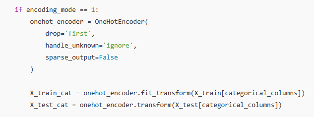

Wenn Modelle(model) auch benutzt werden, dann:

X_train_cat.shape (164, 167)

X_train_num.shape (164, 17)

X_test_cat.shape (41, 167)

X_test_num.shape (41, 17)

Nach dem OneHotEncoding ist dein Feature-Satz 167 + 17 = 184 Features, davon 90 % kategorisch.

### Das Problem der Feature-Dominanz

Bei LinearRegression (oder ähnlichen Modellen) kann ein sehr hohes Verhältnis von kategorischen OHE-Features zu numerischen Features zu Instabilität oder Overfitting führen.

Mein Datensatz hat nur 164 Trainingspunkte – das ist viel weniger als die Anzahl der Features (184).

LinearRegression mit mehr Features als Samples (oder ähnlich groß) gerät in die Nähe von Überanpassung.

Das Modell kann "raten", was zu einem niedrigen Trainingsfehler, aber schlechter Generalisierung führen würde.

Entscheidung: nur Marken benutzen. die Marken können gut den Preis repräsentieren.

### Entscheidung:

Statt einzelner Modelle werden nur Marken berücksichtigt. Marken erfassen den wesentlichen Preiseffekt, während die große Modellvielfalt zu hoher Dimensionalität und instabilen Regressionsschätzern führt.

```python
# Define categorical and numerical columns
# 'model': consider only brand, there ar many models. models are not consiered. if considered, they are overweighted
# other nummerical features are more important for price building
categorical_columns = ['fueltype', 'aspiration',  'carbody', 'drivewheel',
                       'enginelocation', 'enginetype', 'fuelsystem', 'brand']

numerical_columns = ['symboling', 'doornumber','cylindernumber','wheelbase', 'carlength', 'carwidth', 'carheight',
                     'curbweight', 'enginesize', 'boreratio', 'stroke', 'compressionratio', 'horsepower',
                     'peakrpm', 'citympg', 'highwaympg']

print(df["fueltype"].unique(), df["aspiration"].unique(),  df["carbody"].unique(), df["drivewheel"].unique(), df["enginelocation"].unique(),
      df["enginetype"].unique(), df["fuelsystem"].unique())

print(df["enginesize"].unique())
```

```
['gas' 'diesel'] ['std' 'turbo'] ['open' 'utility' 'passenger'] ['rwd' 'fwd' '4wd'] ['front' 'rear'] ['dohc' 'ohc_family' 'simple' 'rotor'] ['fuel_injection' 'carburetor' 'diesel_injection']
[130 152 109 136 131 108 164 209  61  90  98 122 156  92  79 110 111 119
 258 326  91  70  80 140 134 183 234 308 304  97 103 120 181 151 194 203
 132 121 146 171 161 141 173 145]
```

# 4. Modeling (ML-Maschinelles Lernen)

**Mathematische Grundlage: die Kleinste-Quadrate-Methode**

## 4.1 Der allgemeine lineare Fall

1. model = LinearRegression()
2. model.fit(X_train, y_train)

### 4.1.1 Ein eindimensionles Linear-Regression:

y= a*x + b; x, y: Messwerte; a: Steigerung, b: bias

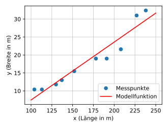

### 4.1.2 N-dimensionles Linear-Regression:

### die Kleinste-Quadrate-Methode(KQM)

### r= Xα - y;

m x (n+1) ; m: Anzahl der Beobachtungen(oder Anzahl der Zeilen in einer Spalte)

a=(a0, a1, a2,... an), n+1-Dimension, Unbekannte; a0: bias

X: mx(n+1) dimensionale Matrix (Beobachtungen-> Xi,j: i Zeile; j: Spalte

y: m-Messwerte (Preise)

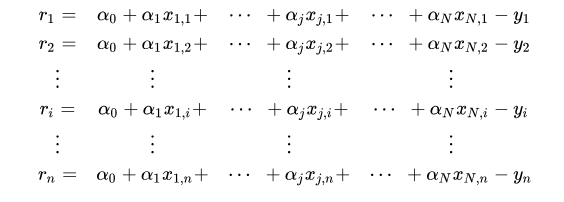

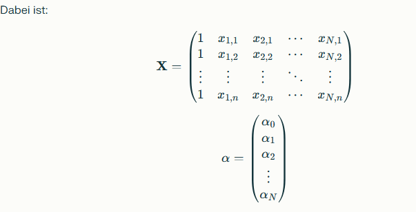

Ziel: die Summe durch KQM zu minimieren

Die Lösung: np.linalg.inv()

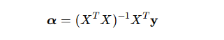

### Achtung

1. **Bedingung für eindeutige Lösung**  
   Damit die Matrix $A^T A$ stabil invertierbar ist, muss die Anzahl der **Zeilen (Beobachtungen)** stets **größer** sein als die Anzahl der **Spalten (Variablen/Features)**.  
   Ist das nicht der Fall, existiert keine eindeutige Lösung für das Gleichungssystem.
2. **Lineare Unabhängigkeit der Spalten**  
   Werden neue Spalten aus bestehenden Daten erzeugt, dürfen sie **nicht in einem proportionalen Verhältnis** zu anderen Spalten stehen. Andernfalls sind die Spalten **linear abhängig**, und die Matrix (A^T A) wird **singulär** (nicht invertierbar).
   - In diesem Fall liefert `np.linalg.inv()` keine echte Inverse, sondern bestenfalls eine **Pseudo-Inverse** (z. B. über `np.linalg.pinv()`), was mathematisch problematisch ist.
   - Beispiel:
   - $x_1 = a \cdot x$ → ❌ **nicht erlaubt** (linear abhängig)
   - $x_1 = \sqrt{x}$ → ✅ **erlaubt** (nicht linear abhängig)

## 4.2 Verfahren von Encoding:

Im Rahmen des Projektes werden bei Encoding für katogorischen Daten zwei Verfahren angewendet: OneHotEncoder und LabelEncoder und OrdinalEncoder. das lässt sich am besten mit Beispielen erklären:

### Beispiel: Encoding von Kategorien

zwei Kategorien:

- **carbody**: `["sedan", "hatchback", "wagon", "convertible", "hardtop"]`
- **enginetype**: `["ohc", "l", "dohc", "dohcv", "ohcf", "ohcv", "rotor"]`

Beispieldaten:

| carbody | enginetype |
| --- | --- |
| sedan | ohc |
| hatchback | l |
| wagon | dohc |
| convertible | dohcv |
| hardtop | ohcv |
| sedan | rotor |

### 4.2.1 LabelEncoder

**from sklearn.preprocessing import LabelEncoder**

#### LabelEncoder aus sklearn.preprocessing wird benutzt, um kategoriale Labels (Strings) in numerische Klassen (0, 1, 2, …) umzuwandeln.

**Wichtig** : Er ist für Zielvariablen (y) bei Klassifikation gedacht, nicht für Feature-Spalten X(dafür eher OneHotEncoder). LabelEncoder + CrossEntropy

LabelEncoder = einzelspaltiges Ordinal-Encoding.

- le_carbody = LabelEncoder(): hat eigenen Encoder le_carbody für Carbody
- le_enginetype = LabelEncoder(): hat eigenen Encoder le_enginetype für enginetype

Das Beispiel dient nur zu Demonstrationszwecken und zeigt eine mögliche numerische Kodierung kategorialer Daten. In der Praxis sollten kategoriale Features (categorical_columns) nicht mit LabelEncoder kodiert werden, da dadurch eine künstliche Ordnung(aber in den Featuredaten nicht stimmt) eingeführt wird.

label_encoders = {}

```
    for column in categorical_columns:

        le = LabelEncoder()

        df_cp[column] = le.fit_transform(df_cp[column])

        label_encoders[column] = le
```

Jede Kategorie wird durch eine **Ganzzahl** (sortiert nach der Bezeichnung, z.B. ['Z', 'G', 'B'], nach Sortierung: ['B','G','Z'], B=0, G=1, Z=2 dargestellt.

Beispielausgabe:

- **Carbody classes:** `['convertible', 'hardtop', 'hatchback', 'sedan', 'wagon']`
- **Enginetype classes:** `['dohc', 'dohcv', 'l', 'ohc', 'ohcf', 'ohcv', 'rotor']`

| carbody | enginetype | carbody_label | enginetype_label |
| --- | --- | --- | --- |
| sedan | ohc | 3 | 3 |
| hatchback | l | 2 | 2 |
| wagon | dohc | 4 | 0 |
| convertible | dohcv | 0 | 1 |
| hardtop | ohcv | 1 | 5 |
| sedan | rotor | 3 | 6 |

Funktionsweise von LabelEncoder

Jede Kategorie bekommt eine ganze Zahl von 0 bis k-1, wobei k die Anzahl der Kategorien in dieser Spalte ist.

Die Reihenfolge wird intern alphabetisch sortiert, es sei denn, es wird explizit eine andere Reihenfolge definiert.

Jede Kategoriegruppe wird unabhängig behandelt, d. h. die Zahlen von carbody_label haben nichts mit enginetype_label zu tun – jede Spalte startet wieder bei 0.

### 4.2.2 OridnalEncoder

Der OrdinalEncoder kann sowohl für Input-Features X als auch für das Target y verwendet werden, sofern eine natürliche Ordnung der Kategorien existiert.

Ein typisches Beispiel sind Schulnoten: 1 = sehr gut, 2 = gut, 3 = befriedigend, 4 = ausreichend, 5 = mangelhaft. Wird der OrdinalEncoder für das Target y eingesetzt, sollte das Problem als ordinale Klassifikation behandelt werden. Dabei kommen spezielle Verfahren zum Einsatz, die die Ordnung der Klassen explizit berücksichtigen. Der zentrale Gedanke besteht darin, eine ordinale Klasse k in mehrere binäre Entscheidungen der Form „Ist y ≥ i?“ zu zerlegen.

z.B. : y ∈ {0,1,2,3,4} (5 Klassen in 4 Klassen als Targets umwandeln, zurück wieder in 5 Klassen)

y ≥ 1 ? y ≥ 2 ? y ≥ 3 ? y ≥ 4 ?

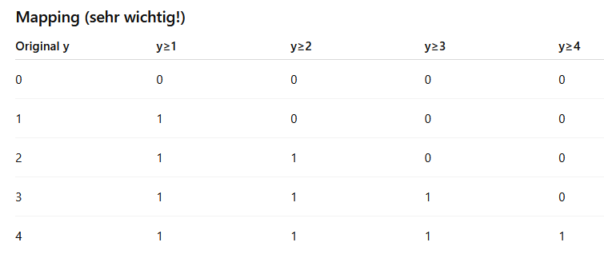

CORN (Conditional Ordinal Regression for NN)

- NN-taugliche Version
- Statt Schwellen:
- mehrere logistische Outputs
- gemeinsamer Feature-Extractor
- einfache Implementierung

Wann solltest du CORN benutzen?

```
- ✔️ Schulnoten
- ✔️ Sternebewertungen
- ✔️ Kredit-Ratings
- ✔️ Zufriedenheitsskalen
- ✔️ juristische Einstufungen
```

Welche Loss-Funktion benutzt man?

- Binary Cross Entropy (BCE), nicht CrossEntropy, nicht MSE

Warum?

- Jede Schwelle ist eine binäre Frage
- Ordnung entsteht durch die Kumulierung

Wie der Rang bei OrdinalEncoder bestimmt wird

1. Standardverhalten (Verhalten wie LabelEncoder)

OrdinalEncoder sortiert alphabetisch jede Kategorie in einer Spalte.

Die erste Kategorie in alphabetischer Reihenfolge bekommt 0, die nächste 1, usw.

2. Jede Spalte wird unabhängig behandelt
3. Numerische Labels spiegeln dann quasi einen „Rang“ wider, aber nur alphabetisch, nicht inhaltlich.
4. OrdinalEncoder = mehrspaltiges Ordinal-Encoding. **enc** als OrdinalEncoder für alle Spalten

**enc** = OrdinalEncoder()

df_ordinal = pd.DataFrame(enc.fit_transform(df), **columns=df.columns**)

**🔹 Eigene Reihenfolge festlegen**

from sklearn.preprocessing import OrdinalEncoder

import pandas as pd

**Benutzerdefinierte Reihenfolge**

carbody_order = ["convertible", "sedan", "wagon", "hatchback", "hardtop"]

enginetype_order = ["dohc", "dohcv", "l", "ohc", "ohcf", "ohcv", "rotor"]

**encoder** = OrdinalEncoder(categories=[carbody_order, enginetype_order])

df_encoded = df.copy()

df_encoded[["carbody", "enginetype"]] = **encoder**.fit_transform(df)

print(df_encoded)

**Ausgabe (selbst definierter Rang)**

| carbody | enginetype | carbody_encoded | enginetype_encoded |
| --- | --- | --- | --- |
| sedan | ohc | 1 | 3 |
| hatchback | l | 3 | 2 |
| wagon | dohc | 2 | 0 |
| convertible | dohcv | 0 | 1 |
| hardtop | ohcv | 4 | 5 |

### Achtung: OrdinalEncoder() darf für das Projekt nicht benutzt werden weil inhaltlich keine Ordnung vorliegen.

## Ein Rechenbeispiel:

```python
import torch

# Beispiel: 5 Klassen (0–4)
y = torch.tensor([0, 1, 2, 3, 4])

def ordinal_targets(y, num_classes):
    return torch.stack([
        (y >= i).float() for i in range(1, num_classes)
    ], dim=1)

y_ord = ordinal_targets(y, num_classes=5)
print("[0, 1, 2, 3, 4]:  ", y_ord)
y = torch.tensor([0, 1, 2, 4])
y_ord = ordinal_targets(y, num_classes=5)
print("[0, 1, 2, 4]:  ", y_ord)
```

```
[0, 1, 2, 3, 4]:   tensor([[0., 0., 0., 0.],
        [1., 0., 0., 0.],
        [1., 1., 0., 0.],
        [1., 1., 1., 0.],
        [1., 1., 1., 1.]])
[0, 1, 2, 4]:   tensor([[0., 0., 0., 0.],
        [1., 0., 0., 0.],
        [1., 1., 0., 0.],
        [1., 1., 1., 1.]])
```

### Schritt 2: Modell

```python
import torch.nn as nn

class OrdinalNet(nn.Module):
    def __init__(self, in_features, num_classes):
        super().__init__()
        self.fc = nn.Linear(in_features, num_classes - 1)

    def forward(self, x):
        return self.fc(x)  # logits

print(OrdinalNet.__dict__)
print("__call__" in nn.Module.__dict__) # Ergibt True
# Zeigt dir alle verfügbaren Methoden inkl. derer von nn.Module
```

```
{'__module__': '__main__', '__init__': <function OrdinalNet.__init__ at 0x0000011C57898B80>, 'forward': <function OrdinalNet.forward at 0x0000011C57898CC0>, '__doc__': None}
True
```

### Schritt 3: Loss (entscheidend!): nn.BCEWithLogitsLoss() for OdinalEncoder

```python
y = torch.tensor([0, 3, 4])
y_ord = ordinal_targets(y, num_classes=5)
# size of y=3 muss  batch_size=3
print("1. y_ord von [0, 3, 4]: \n", y_ord)

in_features=3
model = OrdinalNet(in_features=3, num_classes=5)
criterion = nn.BCEWithLogitsLoss()
batch_size=3
x = torch.randn(batch_size, in_features)
print("2. x:\n", x)
logits = model(x)

loss = criterion(logits, y_ord)
print("3. loss:", loss)
print()
# print("4.dir(model):\n", dir(model)) # für Übungszweck
```

```
1. y_ord von [0, 3, 4]:
 tensor([[0., 0., 0., 0.],
        [1., 1., 1., 0.],
        [1., 1., 1., 1.]])
2. x:
 tensor([[-0.2333, -0.3052, -0.4891],
        [-1.5174, -0.6644,  0.8668],
        [-0.4260, -0.5617, -0.5364]])
3. loss: tensor(0.6691, grad_fn=<BinaryCrossEntropyWithLogitsBackward0>)
```

### Schritt 4: Vorhersage → Ordinale Klasse zurückrechnen

```python
# attention: the model ist not trained here, only as example
print("logits:\n",logits)
probs = torch.sigmoid(logits)
print("probs:\n", probs)
y_pred = (probs > 0.5).sum(dim=1)
print("original: y_ord von [0, 3, 4]: compare with -> estimation: ", y_pred)
```

```
logits:
 tensor([[ 0.1215,  0.9462, -0.3762, -0.4287],
        [ 0.9704,  1.1632,  0.2839,  0.6851],
        [ 0.1790,  1.1712, -0.4952, -0.3415]], grad_fn=<AddmmBackward0>)
probs:
 tensor([[0.5303, 0.7203, 0.4070, 0.3944],
        [0.7252, 0.7619, 0.5705, 0.6649],
        [0.5446, 0.7634, 0.3787, 0.4154]], grad_fn=<SigmoidBackward0>)
original: y_ord von [0, 3, 4]: compare with -> estimation:  tensor([2, 4, 2])
```

### Noch ein Beispiel mit Training: Datensatz (synthetisch, aber realistisch)

```python
# Datensatz (synthetisch, aber realistisch)
import torch
import torch.nn as nn
import torch.optim as optim

torch.manual_seed(0)

# künstliche Features
X = torch.randn(200, 5)

# latenter Score + Rauschen → ordinale Klassen
latent = X[:, 0] + 0.5 * X[:, 1]
y = torch.bucketize(
    latent,
    boundaries=torch.tensor([-1.0, -0.2, 0.5, 1.2])
)

print("Target distribution:", torch.bincount(y))
print("X:\n", X[0:5])
print("y:", y[0:10])
```

```
Target distribution: tensor([29, 53, 47, 40, 31])
X:
 tensor([[-1.1258, -1.1524, -0.2506, -0.4339,  0.8487],
        [ 0.6920, -0.3160, -2.1152,  0.3223, -1.2633],
        [ 0.3500,  0.3081,  0.1198,  1.2377,  1.1168],
        [-0.2473, -1.3527, -1.6959,  0.5667,  0.7935],
        [ 0.5988, -1.5551, -0.3414,  1.8530,  0.7502]])
y: tensor([0, 3, 3, 1, 2, 1, 3, 2, 2, 4])
```

```python
#Ordinale Targets erzeugen (CORN-Style)
def ordinal_targets(y, num_classes):
    return torch.stack(
        [(y >= i).float() for i in range(1, num_classes)],
        dim=1
    )

num_classes = 5
y_ord = ordinal_targets(y, num_classes)
print(y_ord[:10])
```

```
tensor([[0., 0., 0., 0.],
        [1., 1., 1., 0.],
        [1., 1., 1., 0.],
        [1., 0., 0., 0.],
        [1., 1., 0., 0.],
        [1., 0., 0., 0.],
        [1., 1., 1., 0.],
        [1., 1., 0., 0.],
        [1., 1., 0., 0.],
        [1., 1., 1., 1.]])
```

```python
#
# CORN-Modell: CORN (Conditional Ordinal Regression for NN)
# 2 NN layers
# num_classes=5

betw_nn_no = 16  # try with 8
class OrdinalNet(nn.Module):
    def __init__(self, in_features, num_classes):
        super().__init__()
        self.net = nn.Sequential(
            nn.Linear(in_features, betw_nn_no),
            #nn.BatchNorm1d(betw_nn_no),  # <-- Batch Norm (nach Linear oder ReLU)
            nn.ReLU(),
            #nn.Dropout(p=0.2),           # <-- Dropout (20% der Neuronen aus)
            nn.Linear(betw_nn_no, num_classes - 1)
        )
    def forward(self, x):
        return self.net(x)  # logits
```

```python
# Training

model = OrdinalNet(5, num_classes)
optimizer = optim.Adam(model.parameters(), lr=0.01)
criterion = nn.BCEWithLogitsLoss()
epoch_n= 120
for epoch in range(1, epoch_n):
    optimizer.zero_grad()
    logits = model(X)
    loss = criterion(logits, y_ord)
    loss.backward()
    optimizer.step()

    if epoch % 20 == 0:
        print(f"Epoch {epoch:3d} | Loss {loss.item():.4f}")
```

```
Epoch  20 | Loss 0.4947
Epoch  40 | Loss 0.2935
Epoch  60 | Loss 0.1802
Epoch  80 | Loss 0.1274
Epoch 100 | Loss 0.0983
```

```python
# Vorhersage → ordinale Klasse
model.eval() # 1. Layer-Verhalten auf "Vorhersage" stellen
with torch.no_grad():
    logits = model(X)
    probs = torch.sigmoid(logits)
    y_pred = (probs > 0.5).sum(dim=1)

print("True:", y[:10])
print("Pred:", y_pred[:10])
```

```
True: tensor([0, 3, 3, 1, 2, 1, 3, 2, 2, 4])
Pred: tensor([0, 3, 3, 1, 2, 1, 3, 2, 2, 4])
```

### 4.2.3. One-Hot Encoding

Jede Kategorie wird in eine **eigene Spalte mit 0/1** umgewandelt. Es gibt zwei Optionen.

**Option 1**: from sklearn.preprocessing import OneHotEncoder

- ohe = OneHotEncoder(sparse=False, drop='first') oder drop=None als Standard: bekommen den Encoder
- encoded = ohe.fit_transform(df_cp[categorical_columns]):bekommen ein NumPy-Array mit lauter 0/1 (oder evtl. Floats).
- **In DataFrame umwandeln**
- encoded_df = pd.DataFrame( encoded, columns=ohe.get_feature_names_out(categorical_columns), index=df_cp.index ): baut aus dem NumPy-Array wieder ein DataFrame.
- **Original-Daten mit den neuen Spalten kombinieren (alte kategorische Spalten löschen)**
- **df_cp_encoded** = pd.concat( [df_cp.drop(columns=categorical_columns), encoded_df], axis=1): die alten Spalten in df_cp löschen, die neuen Spalten encoded_df mit df_cp in df_cp_encoded zusammenführen

**Option 2**:

- **df_cp_encoded** = pd.get_dummies(df_cp, columns=categorical_columns, drop_first=True or False): sparse=False (Standard): Ganz normales DataFrame mit dichten int64/uint8-Spalten.

**Option1 und Option 2 haben das gleiche Ergebnis, aber Option 2 ist viel einfacher**

#### 4.2.3.1 One-Hot-Encoding: drop_first=False (Standard):

Anwendung: Baum-Modelle (Decision Trees, Random Forest, XGBoost, Gradient Boosting, etc.). Die sind nicht linear und haben kein Multikollinearitätsproblem.

Beispiel:

**carbody** = ["convertible", "sedan", "wagon", "hatchback", "hardtop"]

**enginetype** = ["dohc", "dohcv", "l", "ohc", "ohcf", "ohcv", "rotor"]

Jede Kategorien wird als eine eigene Spalte definiert.

Carbody: 5 Kategorien: 5 Spalten

Enginetype : 7 Kategorien: 7 Spalten

Insgesamt: Es entstehen 12 Spalten bei Encoding:

Wenn z.B. Daten 205 Zeilen haben, jede Spalte der Kategorie hat auch 205 Werte. die fehlende Werte der Spalte sind mit null gefüllt.

Merkmal: Diagoale=1

| Kategorie | sedan | hatchback | wagon | convertible | hardtop | ohc | l | dohc | dohcv | ohcf | ohcv | rotor |
| --- | --- | --- | --- | --- | --- | --- | --- | --- | --- | --- | --- | --- |
| sedan | 1 | 0 | 0 | 0 | 0 | 0 | 0 | 0 | 0 | 0 | 0 | 0 |
| hatchback | 0 | 1 | 0 | 0 | 0 | 0 | 0 | 0 | 0 | 0 | 0 | 0 |
| wagon | 0 | 0 | 1 | 0 | 0 | 0 | 0 | 0 | 0 | 0 | 0 | 0 |
| convertible | 0 | 0 | 0 | 1 | 0 | 0 | 0 | 0 | 0 | 0 | 0 | 0 |
| hardtop | 0 | 0 | 0 | 0 | 1 | 0 | 0 | 0 | 0 | 0 | 0 | 0 |
| ohc | 0 | 0 | 0 | 0 | 0 | 1 | 0 | 0 | 0 | 0 | 0 | 0 |
| l | 0 | 0 | 0 | 0 | 0 | 0 | 1 | 0 | 0 | 0 | 0 | 0 |
| dohc | 0 | 0 | 0 | 0 | 0 | 0 | 0 | 1 | 0 | 0 | 0 | 0 |
| dohcv | 0 | 0 | 0 | 0 | 0 | 0 | 0 | 0 | 1 | 0 | 0 | 0 |
| ohcf | 0 | 0 | 0 | 0 | 0 | 0 | 0 | 0 | 0 | 1 | 0 | 0 |
| ohcv | 0 | 0 | 0 | 0 | 0 | 0 | 0 | 0 | 0 | 0 | 1 | 0 |
| rotor | 0 | 0 | 0 | 0 | 0 | 0 | 0 | 0 | 0 | 0 | 0 | 1 |

Jede Kategorie bekommt eine eigene Spalte wie oben 12 Spalten.

**Es entsteht eine lineare Abhängigkeit wegen der Spalte "Bias"(hat den Werte 1) in der Gleichung:**

Wenn man z. B. carbody=["sedan","hatchback","wagon"] hat, dann entstehen 3 Dummy-Spalten.

🔹 Matrix-Darstellung

Das One-Hot-Encoding ergibt die Designmatrix X:

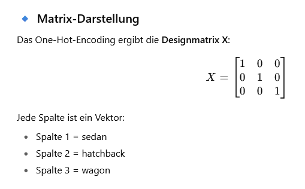

Aber: In einem Regressionsmodell mit Bias/Intercept ändert sich die Situation

Lineares Modell mit Intercept

y = β0 + β1⋅sedan + β2⋅hatchback + β3⋅wagon

β0 ist Bias (Intercept) der Intercept (entspricht einer Spalte voller Einsen).

Designmatrix mit Intercept + Dummies

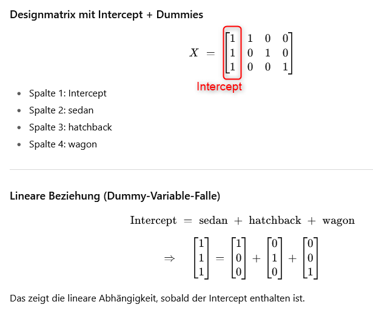

Und diese zusätzliche Spalte voller Einsen bringt die lineare Abhängigkeit ins Spiel.

**Zusammenfassung**:

- Jede Zeile hat genau eine 1.
- Eine Spalte kann mehrere 1en enthalten, da die entsprechende Kategorie in verschiedenen Zeilen vorkommen kann.
- Wenn man alle One-Hot-Spalten einer Zeile summiert, ergibt sich immer 1 – das entspricht dem Effekt der Bias-Spalte im Modell.

**Die Lösung für die lineare Abhängigkeit: drop_first=True**

#### 4.2.3.2 One-Hot-Encoding: (drop_first=True): geeignet für LinearRegression()

Anwendung: Lineare Modelle (z. B. Lineare Regression, Logistische Regression, GLMs).

Die erste Kategorie jeder Kategoriegruppe wird nicht als Spalte definiert, z.B. hier für sedan:pos(sedan,hatchback)=0 dargestellt. Das gleiche gilt für ohc: pos(ohc, l)=0

Merkmal: Diagoale= 0 für die kategorischen Spalten.

| Kategorie | hatchback | wagon | convertible | hardtop | l | dohc | dohcv | ohcf | ohcv | rotor |
| --- | --- | --- | --- | --- | --- | --- | --- | --- | --- | --- |
| **sedan** | 0 | 0 | 0 | 0 | 0 | 0 | 0 | 0 | 0 | 0 |
| hatchback | 1 | 0 | 0 | 0 | 0 | 0 | 0 | 0 | 0 | 0 |
| wagon | 0 | 1 | 0 | 0 | 0 | 0 | 0 | 0 | 0 | 0 |
| convertible | 0 | 0 | 1 | 0 | 0 | 0 | 0 | 0 | 0 | 0 |
| hardtop | 0 | 0 | 0 | 1 | 0 | 0 | 0 | 0 | 0 | 0 |
| ohc | 0 | 0 | 0 | 0 | 0 | 0 | 0 | 0 | 0 | 0 |
| l | 0 | 0 | 0 | 0 | 1 | 0 | 0 | 0 | 0 | 0 |
| dohc | 0 | 0 | 0 | 0 | 0 | 1 | 0 | 0 | 0 | 0 |
| dohcv | 0 | 0 | 0 | 0 | 0 | 0 | 1 | 0 | 0 | 0 |
| ohcf | 0 | 0 | 0 | 0 | 0 | 0 | 0 | 1 | 0 | 0 |
| ohcv | 0 | 0 | 0 | 0 | 0 | 0 | 0 | 0 | 1 | 0 |
| rotor | 0 | 0 | 0 | 0 | 0 | 0 | 0 | 0 | 0 | 1 |

Das Beispiel:

Carbody: 5 Kategorien, eine Kategorie wird weggelassen: 4 Spalten

Enginetype : 7 Kategorien, eine Kategorie wird weggelassen: 6 Spalten

Ingesamt: es entstehen 10 Spalten bei Encoding

Wenn z.B. Daten 200 Zeilen haben, jede Spalte der Kategorie hat auch 200 Werte. die fehlende Werte der Spalte sind mit null gefüllt.

## Vergleich: LabelEncoder/OrdinalEncoder vs. OneHotEncoder

| Kriterium | LabelEncoder/OrdinalEncoder | One-Hot Encoding |
| --- | --- | --- |
| **Darstellung** | Jede Kategorie → eine Zahl | Jede Kategorie → eigene Spalte mit 0/1 |
| **Speicherbedarf** | Sehr gering (nur eine Spalte) | Höher (eine Spalte pro Kategorie) |
| **Interpretation** | Problematisch: Modell denkt, Zahlen hätten Reihenfolge | Klar & eindeutig, keine künstliche Reihenfolge |
| **Gut für** | Entscheidungsbäume, Random Forest | Lineare Modelle, Neuronale Netze |
| **Schlecht für** | Lineare Modelle (da künstliche Rangordnung) | Viele Kategorien (führt zu sehr breiten Matrizen) |

**In der Projektarbeit werden folgende Verfahren untersucht:**

1. Kategorische Spalten benutzt OnehotEncoder + numerische Spalten (standardisiert) → lineares Modell
2. Kategorische Spalten benutzt OrdinalEncoder + numerische Spalten (standardisiert) → lineares Modell
3. Kategorische Spalten benutzt OnehotEncoder + numerische Spalten (standardisiert) + Ausreißer behandeln → lineares Modell
- Aufbereitung von highwaympg: limit_highwaympg_r=52
- Wenn highwaympg > 52, die Zeile wird als Ausreißer gelöscht. Es gibt zwei Ausreißer
4. Kategorische Spalten benutzt OnehotEncoder + numerische Spalten (standardisiert) + neue Spalten durch $x_1 = \sqrt{x}$, $x_2 = x^2$

was bedeutet "standardisiert"?

StandardScaler() ist ein Werkzeug aus scikit-learn, das numerische Features standardisiert: Es bringt alle angegebenen Spalten (Features) auf eine gemeinsame Skala, indem jeder Wert so transformiert wird:

Dabei ist **x** der Originalwert, **μ** der Mittelwert und **σ** die Standardabweichung der jeweiligen Spalte.

fit_transform() berechnet zuerst Mittelwert und Standardabweichung für jede numerische Spalte – und transformiert dann alle Werte entsprechend.

Das Ergebnis: Alle Werte der angegebenen numerischen Spalten haben danach Mittelwert=0 und Standardabweichung=1. Die Skalierung ist jetzt vergleichbar, egal ob z.B. Einkommen, Alter oder Wohnfläche vorher unterschiedlich große Zahlen waren.

## 4.3 Funktionsdefinition für Modelltraining und Vorhersage:

### 4.3.1 training_carmodel() + predict_price()

### df_cp: data Frame

### categorical_columns = ['fueltype', 'aspiration', 'carbody', 'drivewheel','enginelocation', 'enginetype', 'fuelsystem', 'brand']

### numerical_columns = ['symboling', 'doornumber','cylindernumber','wheelbase', 'carlength', 'carwidth', 'carheight','curbweight', 'enginesize', 'boreratio', 'stroke', 'compressionratio', 'horsepower','peakrpm', 'citympg', 'highwaympg']

### test_daten_size:

- =0.2: 20% der Daten als Testdaten, 80% als Trainingsdaten

### squared_cols: 0, 1, 2; 0: keine neue Spalten; für für numerische Spalten

- **1:** $x_1 = \sqrt{x}$ ; falls $x < 0 \;\Rightarrow\; x_1 = -\sqrt{|x|}$
- **2:** $x_2 = x^2$

### 4.3.2 Voraussetzung: categorical_columns und numerical_columns sind definiert

- categorical_columns = ['fueltype', 'aspiration', 'carbody', 'drivewheel', 'enginelocation', 'enginetype', 'fuelsystem', 'brand']
- numerical_columns = ['symboling', 'doornumber','cylindernumber','wheelbase', 'carlength', 'carwidth', 'carheight', 'curbweight', 'enginesize', 'boreratio', 'stroke', 'compressionratio', 'horsepower', 'peakrpm', 'citympg', 'highwaympg']

### 4.3.3 Dokumentation: Scaling & Ordinal-Encoding für ML

#### 1️⃣ Numerische Werte: StandardScaler

Beim maschinellen Lernen ist es üblich, numerische Features zu standardisieren, damit sie vergleichbare Skalen haben. Dies verbessert die Stabilität und Geschwindigkeit vieler Modelle.

##### Training

```
scaler = StandardScaler()
df_cp[numerical_columns] = scaler.fit_transform(df_cp[numerical_columns])
```

- `fit_transform()` berechnet Mittelwert (mean) und Standardabweichung (std) und wendet sie an: $(x_{scaled} = \frac{x - mean}{std}$)
- Die Mittelwerte und Standardabweichungen werden im `scaler` gespeichert.

##### Vorhersage / neue Daten

```
df_test[numerical_columns] = scaler.transform(df_test[numerical_columns])
```

- Nur `transform()` wird verwendet, um die gleiche Skalierung wie beim Training zu garantieren.
- Nie `fit_transform()` auf neuen Daten verwenden!

#### 2️⃣ Kategoriale Werte: Ordinal-Encoding (LabelEncoder)

##### Training

```
label_encoders = {}
for column in categorical_columns:
    le = LabelEncoder()
    df_cp[column] = le.fit_transform(df_cp[column])
    label_encoders[column] = le
```

- Für jede Spalte ein eigener Encoder.
- `fit_transform()` lernt die Kategorien und wandelt sie in Zahlen um.
- Die Encoder werden gespeichert, um bei Vorhersagen dieselbe Kodierung zu nutzen.

##### Vorhersage / neue Daten

```
if label_encoders is not None:
    for column in categorical_columns:
        df_test[column] = label_encoders[column].transform(df_test[column])
```

- Die Spalten werden mit den gespeicherten Encodern transformiert.
- Neue, unbekannte Kategorien führen zu einem Fehler.

#### 3 Zusammenfassung

| Feature-Typ | Training | Vorhersage | Warum wichtig |
| --- | --- | --- | --- |
| Numerisch | `fit_transform()` | `transform()` | Konsistente Standardisierung |
| Kategorial (Ordinal) | `fit_transform()` + Encoder speichern | `transform()` mit gespeichertem Encoder | Konsistente Kodierung |

## Im Projektarbeit: OrdinalEncoder(LabelEncoder) für Features (bewusst „falsch“ getestet)

Wirkung:

Jede Kategorie wird zu 0,1,2,3,…

LinearRegression interpretiert:

Ordnung

Abstände

Linearität

Das Modell lernt implizit:

gas = diesel + 1

❌ Semantisch falsch ❌ Ökonomisch unsinnig ❌ Statistisch verzerrend

3️⃣ Warum dein Modell trotzdem „funktioniert“

Und jetzt kommt der wichtige Punkt, den viele nicht verstehen – du aber implizit richtig getestet hast:

❗ LinearRegression kann mit LabelEncoded Features trainieren

Keine mathematische Singularität

Kein numerischer Fehler

R² kann sogar hoch aussehen

Aber:

### 👉 Das Modell lernt falsche Zusammenhänge

## training_carmodel_old()

```python
# odl code in the version 1.0
# problem:
# 1. Data Leakage;
# 2. OrdinalEncoder for cat. colunms
#
from sklearn.preprocessing import LabelEncoder, StandardScaler
from sklearn.model_selection import train_test_split
from sklearn.linear_model import LinearRegression
from sklearn.metrics import mean_squared_error, r2_score
import pandas as pd
import numpy as np

def training_carmodel_old(df_cp, categorical_columns, numerical_columns,
                      encoding_mode=1, test_daten_size=0.2, squared_cols=0):
    """
    Trainiert ein lineares Regressionsmodell auf Auto-Daten.

    Parameters:
    -----------
    df_cp : pd.DataFrame
        Trainingsdaten inklusive Zielspalte 'price'.
    categorical_columns : list
        Liste der kategorialen Spalten.
    numerical_columns : list
        Liste der numerischen Spalten.
    encoding_mode : int
        1 = One-Hot Encoding, 2 = Ordinal (Label) Encoding
    test_daten_size : float
        Anteil der Daten für den Testsplit.
    squared_cols : int
        0 = keine Transformation, 1 = sqrt Transformation, 2 = quadrieren

    Returns:
    --------
    model : LinearRegression
        Trainiertes Regressionsmodell
    label_encoders : dict
        Dictionary mit LabelEncodern für jede kategoriale Spalte (nur bei encoding_mode=2)
    scaler : StandardScaler
        Scaler für numerische Spalten
    mse : float
        Mean Squared Error auf Testdaten
    r2_square : float
        R^2 Score auf Testdaten
    pred_df : pd.DataFrame
        Vergleich von tatsächlichen und vorhergesagten Preisen
    """

    # ----------------------
    # Encoding
    # ----------------------
    if encoding_mode == 1:
        df_cp = pd.get_dummies(df_cp, columns=categorical_columns, drop_first=True)
        label_encoders = None
    else:
        label_encoders = {}
        for column in categorical_columns:
            le = LabelEncoder()
            df_cp[column] = le.fit_transform(df_cp[column])
            label_encoders[column] = le

    # ----------------------
    # Feature Engineering
    # ----------------------
    df_cp['power_to_weight_ratio'] = df_cp['horsepower'] / df_cp['curbweight']
    #df_cp['log_enginesize'] = np.log(df_cp['enginesize'] + 1.2)


    for column in numerical_columns:
        if squared_cols == 2:  #x^2
            df_cp[f'{column}_squared'] = df_cp[column] ** 2
        elif squared_cols == 1:  # sqrt(x)
            df_cp[f'{column}_squared'] = np.where(
                df_cp[column] <= 0,
                -np.sqrt(abs(df_cp[column])),
                np.sqrt(abs(df_cp[column]))
            )

    # ----------------------
    # Scaling
    # ----------------------
    scaler = StandardScaler()
    df_cp[numerical_columns] = scaler.fit_transform(df_cp[numerical_columns])

    # ----------------------
    # Train-Test-Split
    # ----------------------
    X = df_cp.drop(['price', 'car_ID', 'CarName'], axis=1)
    y = df_cp['price']
    X_train, X_test, y_train, y_test = train_test_split(X, y, test_size=test_daten_size, random_state=42)

   # print("Rows:", len(df_cp), "columns", len(df_cp.columns) )

    # ----------------------
    # Modelltraining
    # ----------------------
    model = LinearRegression()
    model.fit(X_train, y_train)

    # ----------------------
    # Vorhersagen
    # ----------------------
    y_pred = model.predict(X_test)

    # ----------------------
    # Modellbewertung
    # ----------------------
    mse = mean_squared_error(y_test, y_pred)
    r2_square = r2_score(y_test, y_pred)

    pred_df = pd.DataFrame({
        'Actual Value': y_test,
        'Predicted Value': y_pred,
        'Difference': y_test - y_pred,
        'rel%': abs((y_test - y_pred)) / y_test * 100
    })

    #print(f"r2_score: {r2_score:.4f}, MSE: {mse:.2f}")

    return model, label_encoders, scaler, mse, r2_square, pred_df


def predict_price_old(df_test, model, label_encoders, scaler, categorical_columns, numerical_columns,
                  squared_cols=0):
    """
    Macht Vorhersagen für neue Auto-Daten basierend auf einem trainierten Modell.

    Parameters:
    -----------
    df_test : pd.DataFrame
        Neue Daten zum Vorhersagen
    model : LinearRegression
        Trainiertes Modell
    label_encoders : dict
        LabelEncoder pro kategorialer Spalte (nur bei Ordinal-Encoding)
    scaler : StandardScaler
        Scaler für numerische Spalten
    categorical_columns : list
        Liste der kategorialen Spalten
    numerical_columns : list
        Liste der numerischen Spalten
    squared_cols : int
        0 = keine Transformation, 1 = sqrt Transformation, 2 = quadrieren

    Returns:
    --------
    y_pred : np.ndarray
        Vorhergesagte Preise
    """

    # ----------------------
    # Encoding
    # ----------------------
    if label_encoders is not None:
        for column in categorical_columns:
            df_test[column] = label_encoders[column].transform(df_test[column])

    # ----------------------
    # Feature Engineering
    # ----------------------
    df_test['power_to_weight_ratio'] = df_test['horsepower'] / df_test['curbweight']
    #df_test['log_enginesize'] = np.log(df_test['enginesize'] + 1.2)


    for column in numerical_columns:
        if squared_cols == 2:
            df_test[f'{column}_squared'] = df_test[column] ** 2
        elif squared_cols == 1:
            df_test[f'{column}_squared'] = np.where(
                df_test[column] <= 0,
                -np.sqrt(abs(df_test[column])),
                np.sqrt(abs(df_test[column]))
            )

    # ----------------------
    # Scaling
    # ----------------------
    df_test[numerical_columns] = scaler.transform(df_test[numerical_columns])

    # ----------------------
    # Features für Prediction vorbereiten
    # ----------------------
    drop_cols = ['car_ID', 'CarName']
    if 'price' in df_test.columns:
        drop_cols.append('price')
    X_new = df_test.drop(drop_cols, axis=1)

    # ----------------------
    # Prediction
    # ----------------------
    y_pred = model.predict(X_new)
    return y_pred
```

```python
import numpy as np
import pandas as pd

from sklearn.preprocessing import (
    OrdinalEncoder,
    StandardScaler,
    OneHotEncoder
)
from sklearn.model_selection import train_test_split
from sklearn.linear_model import LinearRegression, Ridge
from sklearn.metrics import mean_squared_error, r2_score
import warnings
warnings.filterwarnings("ignore", category=UserWarning)
```

## training_carmodel_CV()

```python
# training_carmodel_CV
import pandas as pd
import numpy as np
from sklearn.model_selection import StratifiedKFold
from sklearn.preprocessing import OneHotEncoder, OrdinalEncoder, StandardScaler
from sklearn.linear_model import LinearRegression
from sklearn.metrics import mean_squared_error, r2_score

global count_train
count_train = 0

def training_carmodel_CV(
    df_cp,
    categorical_columns,
    numerical_columns,
    encoding_mode="onehot",   # "onehot" | "ordinal"
    n_splits=5,
    squared_cols=0
):
    """
    Train a linear regression model for car price prediction using StratifiedKFold.

    Parameters
    ----------
    df_cp : pandas.DataFrame
        Full dataset containing both features and the target column 'price'.

    categorical_columns : list of str
        Names of categorical feature columns.

    numerical_columns : list of str
        Names of numerical feature columns.

    encoding_mode : str, default="onehot"
        "onehot" or "ordinal"

    n_splits : int, default=5
        Number of folds for StratifiedKFold.

    squared_cols : int, default=0
        Optional nonlinear transformations: 0=None, 1=sqrt, 2=square

    Returns
    -------
    model : trained LinearRegression model on all data
    ordinal_encoders : dict or None
    onehot_encoder : fitted OneHotEncoder or None
    scaler : fitted StandardScaler
    feature_names : list of final feature names
    cv_results : DataFrame with MSE/R2 per fold
    pred_df : DataFrame of predictions on all data (final model)
    """

    global count_train
    df_cp = df_cp.copy()
    X = df_cp.drop(columns=["price"])
    y = df_cp["price"]

    # Stratified bins für Regression
    y_bins = pd.qcut(y, q=5, duplicates='drop')

    # Stratified KFold
    skf = StratifiedKFold(n_splits=n_splits, shuffle=True, random_state=42)

    fold_results = []

    for fold, (train_idx, test_idx) in enumerate(skf.split(X, y_bins), 1):
        X_train, X_test = X.iloc[train_idx], X.iloc[test_idx]
        y_train, y_test = y.iloc[train_idx], y.iloc[test_idx]

        # --------------------------------------------------
        # Categorical Encoding
        # --------------------------------------------------
        onehot_encoder = None
        ordinal_encoders = None

        if encoding_mode == "onehot":
            onehot_encoder = OneHotEncoder(
                drop="first",
                handle_unknown="ignore",
                sparse_output=False
            )

            X_train_cat = onehot_encoder.fit_transform(
                X_train[categorical_columns]
            )
            X_test_cat = onehot_encoder.transform(
                X_test[categorical_columns]
            )

            cat_feature_names = onehot_encoder.get_feature_names_out(
                categorical_columns
            )

            X_train_cat = pd.DataFrame(
                X_train_cat,
                columns=cat_feature_names,
                index=X_train.index
            )

            X_test_cat = pd.DataFrame(
                X_test_cat,
                columns=cat_feature_names,
                index=X_test.index
            )

        elif encoding_mode == "ordinal":
            ordinal_encoders = {}
            X_train_cat = pd.DataFrame(index=X_train.index)
            X_test_cat = pd.DataFrame(index=X_test.index)

            for col in categorical_columns:
                oe = OrdinalEncoder(
                    handle_unknown="use_encoded_value",
                    unknown_value=-1
                )

                X_train_cat[col] = oe.fit_transform(X_train[[col]]).ravel()
                X_test_cat[col] = oe.transform(X_test[[col]]).ravel()
                ordinal_encoders[col] = oe

        else:
            raise ValueError("encoding_mode must be 'onehot' or 'ordinal'")

        # --------------------------------------------------
        # Numerical Features + Feature Engineering
        # --------------------------------------------------
        X_train_num = X_train[numerical_columns].copy()
        X_test_num = X_test[numerical_columns].copy()

        # Engineered feature (power_to_weight_ratio)
        X_train_num["power_to_weight_ratio"] = (
            X_train["horsepower"] / X_train["curbweight"].replace(0, np.nan)
        ).fillna(0)
        X_test_num["power_to_weight_ratio"] = (
            X_test["horsepower"] / X_test["curbweight"].replace(0, np.nan)
        ).fillna(0)

        # Optional nonlinear transformations
        for col in numerical_columns:
            if squared_cols == 2:
                X_train_num[f"{col}_squared"] = X_train[col] ** 2
                X_test_num[f"{col}_squared"] = X_test[col] ** 2
            elif squared_cols == 1:
                X_train_num[f"{col}_squared"] = np.sqrt(np.abs(X_train[col]))
                X_test_num[f"{col}_squared"] = np.sqrt(np.abs(X_test[col]))

        # Scaling
        scaler = StandardScaler()
        X_train_num = pd.DataFrame(
            scaler.fit_transform(X_train_num),
            columns=X_train_num.columns,
            index=X_train_num.index
        )
        X_test_num = pd.DataFrame(
            scaler.transform(X_test_num),
            columns=X_test_num.columns,
            index=X_test_num.index
        )

        # Final Design Matrices
        X_train_final = pd.concat([X_train_num, X_train_cat], axis=1)
        X_test_final = pd.concat([X_test_num, X_test_cat], axis=1)

        feature_names = X_train_final.columns

        # Model Training
        model = LinearRegression()
        model.fit(X_train_final, y_train)

        # Evaluation
        y_pred = model.predict(X_test_final)
        mse = mean_squared_error(y_test, y_pred)
        r2 = r2_score(y_test, y_pred)

        fold_results.append({
            "fold": fold,
            "mse": mse,
            "r2": r2
        })

        count_train += 1

    cv_results = pd.DataFrame(fold_results)

    # --------------------------------------------------
    # Final Model auf allen Daten
    # --------------------------------------------------
    # Encoding + Scaling auf kompletter Datenbasis
    if encoding_mode == "onehot":
        onehot_encoder = OneHotEncoder(
            drop="first",
            handle_unknown="ignore",
            sparse_output=False
        )
        X_cat_all = onehot_encoder.fit_transform(X[categorical_columns])
        cat_feature_names = onehot_encoder.get_feature_names_out(categorical_columns)
        X_cat_all = pd.DataFrame(X_cat_all, columns=cat_feature_names, index=X.index)
    else:
        ordinal_encoders = {}
        X_cat_all = pd.DataFrame(index=X.index)
        for col in categorical_columns:
            oe = OrdinalEncoder(handle_unknown="use_encoded_value", unknown_value=-1)
            X_cat_all[col] = oe.fit_transform(X[[col]]).ravel()
            ordinal_encoders[col] = oe

    X_num_all = X[numerical_columns].copy()
    X_num_all["power_to_weight_ratio"] = (X["horsepower"] / X["curbweight"].replace(0, np.nan)).fillna(0)
    for col in numerical_columns:
        if squared_cols == 2:
            X_num_all[f"{col}_squared"] = X[col] ** 2
        elif squared_cols == 1:
            X_num_all[f"{col}_squared"] = np.sqrt(np.abs(X[col]))

    scaler = StandardScaler()
    X_num_all = pd.DataFrame(scaler.fit_transform(X_num_all), columns=X_num_all.columns, index=X.index)

    X_final = pd.concat([X_num_all, X_cat_all], axis=1)
    feature_names = X_final.columns

    final_model = LinearRegression()
    final_model.fit(X_final, y)

    # Predictions auf allen Daten
    y_pred_all = final_model.predict(X_final)
    pred_df = pd.DataFrame({
        "Actual Value": y,
        "Predicted Value": y_pred_all,
        "Difference": y - y_pred_all,
        "rel%": np.abs(y - y_pred_all) / y * 100
    })

    return final_model, ordinal_encoders, onehot_encoder, scaler, feature_names, cv_results, pred_df
```

## training_carmodel()

```python
global count_train

count_train=0
def training_carmodel(
    df_cp,
    categorical_columns,
    numerical_columns,
    encoding_mode="onehot",   # "onehot" | "ordinal"
    test_daten_size=0.2,
    squared_cols=0
):
    global count_train

    """
    Train a linear regression model for car price prediction.

    Parameters
    ----------
    df_cp : pandas.DataFrame
        Full dataset containing both features and the target column
        named 'price'. The DataFrame must include all categorical
        and numerical columns specified below.

    categorical_columns : list of str
        Names of categorical feature columns.
        These columns will be encoded using either One-Hot Encoding
        or Ordinal Encoding depending on `encoding_mode`.

    numerical_columns : list of str
        Names of numerical feature columns.
        These features will be scaled using StandardScaler and may
        optionally receive nonlinear transformations.

    encoding_mode : str, default="onehot"
        Encoding strategy for categorical features:
        - "onehot": One-Hot Encoding using sklearn's OneHotEncoder
                    (recommended for linear models).
        - "ordinal": Ordinal Encoding using OrdinalEncoder with
                     unknown categories mapped to -1
                     (intentionally information-losing; for experiments).

    test_daten_size : float, default=0.2
        Proportion of the dataset to include in the test split.
        Must be a value between 0 and 1.

    squared_cols : int, default=0
        Controls optional nonlinear transformations of numerical features:
        - 0 : No transformation
        - 1 : Square root transformation (sqrt(|x|))
        - 2 : Squared transformation (x²)

    Returns
    -------
    model : sklearn.linear_model.LinearRegression
        Trained linear regression model.

    ordinal_encoders : dict or None
        Dictionary mapping column names to fitted OrdinalEncoder objects.
        Returned only if `encoding_mode="ordinal"`, otherwise None.

    onehot_encoder : sklearn.preprocessing.OneHotEncoder or None
        Fitted OneHotEncoder used during training.
        Returned only if `encoding_mode="onehot"`, otherwise None.

    scaler : sklearn.preprocessing.StandardScaler
        Scaler fitted on the numerical training features.

    feature_names : pandas.Index
        Ordered list of feature names used during training.
        Required to ensure consistent feature alignment during prediction.

    mse : float
        Mean Squared Error evaluated on the test set.

    r2_square : float
        Coefficient of determination (R² score) evaluated on the test set.

    pred_df : pandas.DataFrame
        DataFrame comparing actual target values and model predictions,
        including absolute and relative errors.
    """

    # --------------------------------------------------
    # Defensive copy
    # --------------------------------------------------
    df_cp = df_cp.copy()

    # --------------------------------------------------
    # Train / Test Split (NO leakage!)
    # --------------------------------------------------
    X = df_cp.drop(columns=["price"])
    y = df_cp["price"]

    """ without stratify=y_bins
    X_train, X_test, y_train, y_test = train_test_split(
        X,
        y,
        test_size=test_daten_size,
        random_state=42
    )
    """

    # Stratified bins für Regression
    y_bins = pd.qcut(y, q=5, duplicates='drop')

    X_train, X_test, y_train, y_test = train_test_split(
        X,
        y,
        test_size=test_daten_size,
        random_state=42,
        stratify=y_bins
    )



    # --------------------------------------------------
    # Categorical Encoding
    # --------------------------------------------------
    onehot_encoder = None
    ordinal_encoders = None

    if encoding_mode == "onehot":
        onehot_encoder = OneHotEncoder(
            drop="first",
            handle_unknown="ignore",
            sparse_output=False
        )

        X_train_cat = onehot_encoder.fit_transform(
            X_train[categorical_columns]
        )
        X_test_cat = onehot_encoder.transform(
            X_test[categorical_columns]
        )

        cat_feature_names = onehot_encoder.get_feature_names_out(
            categorical_columns
        )

        X_train_cat = pd.DataFrame(
            X_train_cat,
            columns=cat_feature_names,
            index=X_train.index
        )

        X_test_cat = pd.DataFrame(
            X_test_cat,
            columns=cat_feature_names,
            index=X_test.index
        )

    elif encoding_mode == "ordinal":
        ordinal_encoders = {}

        X_train_cat = pd.DataFrame(index=X_train.index)
        X_test_cat = pd.DataFrame(index=X_test.index)

        for col in categorical_columns:
            oe = OrdinalEncoder(
                handle_unknown="use_encoded_value",
                unknown_value=-1
            )

            X_train_cat[col] = oe.fit_transform(
                X_train[[col]]
            ).ravel()

            X_test_cat[col] = oe.transform(
                X_test[[col]]
            ).ravel()

            ordinal_encoders[col] = oe

    else:
        raise ValueError("encoding_mode must be 'onehot' or 'ordinal'")

    # --------------------------------------------------
    # Numerical Features + Feature Engineering
    # --------------------------------------------------
    X_train_num = X_train[numerical_columns].copy()
    X_test_num = X_test[numerical_columns].copy()

    # Engineered feature (safe division)
    X_train_num["power_to_weight_ratio"] = (
        X_train["horsepower"] /
        X_train["curbweight"].replace(0, np.nan)
    ).fillna(0)

    X_test_num["power_to_weight_ratio"] = (
        X_test["horsepower"] /
        X_test["curbweight"].replace(0, np.nan)
    ).fillna(0)

    # Optional nonlinear transformations
    for col in numerical_columns:
        if squared_cols == 2:
            X_train_num[f"{col}_squared"] = X_train[col] ** 2
            X_test_num[f"{col}_squared"] = X_test[col] ** 2

        elif squared_cols == 1:
            X_train_num[f"{col}_squared"] = np.sqrt(np.abs(X_train[col]))
            X_test_num[f"{col}_squared"] = np.sqrt(np.abs(X_test[col]))

    # --------------------------------------------------
    # Scaling (SAFE Pandas handling)
    # --------------------------------------------------
    scaler = StandardScaler()

    X_train_num = pd.DataFrame(
        scaler.fit_transform(X_train_num),
        columns=X_train_num.columns,
        index=X_train_num.index
    )

    X_test_num = pd.DataFrame(
        scaler.transform(X_test_num),
        columns=X_test_num.columns,
        index=X_test_num.index
    )

    print("X_train:cat, num, X_Test:cat, num", X_train_cat.shape, X_train_num.shape, X_test_cat.shape, X_test_num.shape)

    count_train=count_train+1
    print("count of the trainig: ", count_train)

    # --------------------------------------------------
    # Final Design Matrices
    # --------------------------------------------------
    X_train_final = pd.concat(
        [X_train_num, X_train_cat],
        axis=1
    )

    X_test_final = pd.concat(
        [X_test_num, X_test_cat],
        axis=1
    )

    # 🔒 Save feature order (CRITICAL!)
    feature_names = X_train_final.columns

    # --------------------------------------------------
    # Model Training
    # --------------------------------------------------

    #model = Ridge(alpha=1.0)
    model = LinearRegression()
    model.fit(X_train_final, y_train)

    # --------------------------------------------------
    # Evaluation
    # --------------------------------------------------
    y_pred = model.predict(X_test_final)

    mse = mean_squared_error(y_test, y_pred)
    r2_square = r2_score(y_test, y_pred)

    #print("y_test:\n", y_test)
    pred_df = pd.DataFrame({
        "Actual Value": y_test,
        "Predicted Value": y_pred,
        "Difference": y_test - y_pred,
        "rel%": np.abs(y_test - y_pred) / y_test * 100
    })


    return (
        model,
        ordinal_encoders,
        onehot_encoder,
        scaler,
        feature_names,
        mse,
        r2_square,
        pred_df
    )
```

## def predict_price()

```python
def predict_price(
    df_test,
    model,
    ordinal_encoders,
    onehot_encoder,
    scaler,
    feature_names,
    categorical_columns,
    numerical_columns,
    squared_cols=0
):
    """
    Predict car prices using a trained regression model.

    Parameters
    ----------
    df_test : pandas.DataFrame
        New, unseen data containing the same feature columns
        as used during training (excluding the target column 'price').

    model : sklearn.linear_model.LinearRegression
        Trained regression model returned by `training_carmodel`.

    ordinal_encoders : dict or None
        Dictionary of fitted OrdinalEncoders used during training.
        Must be provided if ordinal encoding was used, otherwise None.

    onehot_encoder : sklearn.preprocessing.OneHotEncoder or None
        Fitted OneHotEncoder from training.
        Must be provided if one-hot encoding was used, otherwise None.

    scaler : sklearn.preprocessing.StandardScaler
        Scaler fitted on the numerical training features.

    feature_names : pandas.Index
        Ordered list of feature names used during training.
        Ensures correct feature alignment during prediction.

    categorical_columns : list of str
        Names of categorical feature columns.

    numerical_columns : list of str
        Names of numerical feature columns.

    squared_cols : int, default=0
        Must match the transformation mode used during training:
        - 0 : No transformation
        - 1 : Square root transformation
        - 2 : Squared transformation

    Returns
    -------
    y_pred : numpy.ndarray
        Predicted car prices for each row in `df_test`.
    """

    df_test = df_test.copy()
    # --------------------------------------------------
    # Encode categorical features
    # --------------------------------------------------
    if onehot_encoder is not None:
        X_cat = onehot_encoder.transform(
            df_test[categorical_columns]
        )

        cat_feature_names = onehot_encoder.get_feature_names_out(
            categorical_columns
        )

        X_cat = pd.DataFrame(
            X_cat,
            columns=cat_feature_names,
            index=df_test.index
        )
    else:
        X_cat = pd.DataFrame(index=df_test.index)
        for col in categorical_columns:
            X_cat[col] = ordinal_encoders[col].transform(
                df_test[[col]]
            ).ravel()

    # --------------------------------------------------
    # Numerical features + feature engineering
    # --------------------------------------------------
    X_num = df_test[numerical_columns].copy()

    X_num["power_to_weight_ratio"] = (
        df_test["horsepower"] /
        df_test["curbweight"].replace(0, np.nan)
    ).fillna(0)

    for col in numerical_columns:
        if squared_cols == 2:
            X_num[f"{col}_squared"] = df_test[col] ** 2
        elif squared_cols == 1:
            X_num[f"{col}_squared"] = np.sqrt(np.abs(df_test[col]))

    # --------------------------------------------------
    # Scaling (SAFE)
    # --------------------------------------------------
    X_num = pd.DataFrame(
        scaler.transform(X_num),
        columns=X_num.columns,
        index=X_num.index
    )

    # --------------------------------------------------
    # Final feature matrix (ORDER MATTERS!)
    # --------------------------------------------------
    X_final = pd.concat([X_num, X_cat], axis=1)
    #print("predict_price:  X_final:", X_final)
    #print(feature_names)

    X_final = X_final[feature_names]

    # --------------------------------------------------
    # Prediction
    # --------------------------------------------------
    y_pred = model.predict(X_final)

    return y_pred
```

### 4.3.4 Erklärung von r2_score(y_test, y_pred)

**R² (Bestimmtheitsmaß) - Erklärung**

### 1️⃣ Definition von R² (Bestimmtheitsmaß)

Für ein Test-Set gilt:

### R² = 1 - (Σ(y_i - ŷ_i)² / Σ(y_i - ȳ)²)

#### - y_i = echte Werte

#### - ŷ_i = vorhergesagte Werte

#### - ȳ = Mittelwert der echten Werte

Interpretation:

- R² = 1 → perfekte Vorhersage
- R² = 0 → Modell sagt genauso gut wie Mittelwert
- R² < 0 → Modell ist schlechter als Mittelwert

### 2️⃣ Wann wird R² negativ?

### Σ(y_i - ŷ_i)² > Σ(y_i - ȳ)²

- Das passiert, wenn dein Modell die Werte so schlecht vorhersagt, dass der Mittelwert eine bessere Vorhersage liefern würde.
- Typische Ursachen:
  - Lineares Modell auf nichtlinearen Zusammenhängen
  - Zu wenige oder falsche Features
  - Ausreißer im Test-Set
  - Übermäßiges Rauschen in den Daten

Negatives R² ist ein Warnsignal, dass dein Modell nicht gut passt. Es bedeutet nicht, dass der Wert falsch berechnet wurde.

## 4.4 Methodische Untersuchung für das Modelltraining

### 4.4.1 Kategorische Spalten mit One-Hot-Encoding + numerische Spalten (standardisiert) → lineares Modell

additional information:

if models are considered and there are no reduction of other categorical colums items, then:

- X_train_cat.shape (164, 167)
- X_train_num.shape (164, 17)
- X_test_cat.shape (41, 167)
- X_test_num.shape (41, 17)

#### more feature columns than train rows: not ok

  The result is not deterministic!!

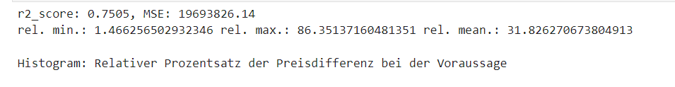

```
X_train:cat, num, X_Test:cat, num (164, 33) (164, 17) (41, 33) (41, 17)
count of the trainig:  1
r2_score: 0.9531, MSE: 2509925.62
rel %. min.: 0.20732441309382127 rel. max.: 34.42074274770881 rel. mean.: 11.423852108442194

Histogram: Relativer Prozentsatz der Preisdifferenz bei der Voraussage
```

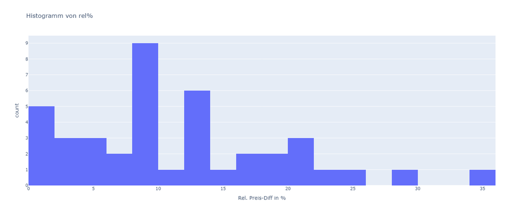

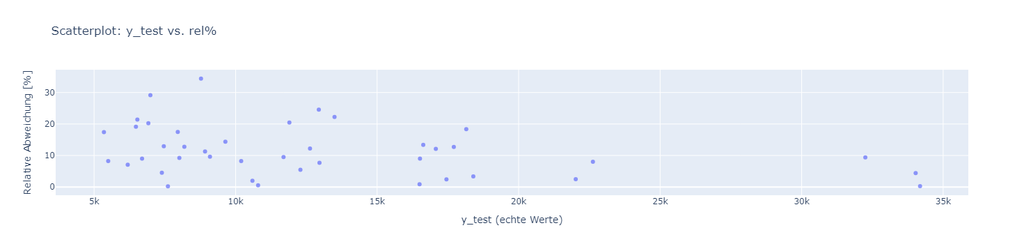

```
     Actual Value  Predicted Value  Difference   rel%
155        8778.0          5756.55     3021.45  34.42
85         6989.0          9028.05    -2039.05  29.18
194       12940.0         16118.86    -3178.86  24.57
0         13495.0         16500.00    -3005.00  22.27
33         6529.0          7927.81    -1398.81  21.42
107       11900.0         14335.01    -2435.01  20.46
153        6918.0          5515.45     1402.55  20.27
30         6479.0          5240.29     1238.71  19.12
136       18150.0         14813.74     3336.26  18.38
119        7957.0          6565.02     1391.98  17.49
150        5348.0          6279.65     -931.65  17.42
168        9639.0         11026.26    -1387.26  14.39
115       16630.0         14406.17     2223.83  13.37
146        7463.0          8427.18     -964.18  12.92
86         8189.0          9234.49    -1045.49  12.77
```

```python
#One-Hot Encoder
#training_carmodel(1, test_daten_size=0.2, squared_cols=0)
"""
def training_carmodel(
    df_cp,
    categorical_columns,
    numerical_columns,
    encoding_mode="onehot",   # "onehot" | "ordinal"
    test_daten_size=0.2,
    squared_cols=0
):

"""
df_cp= df.copy(deep= True)
model, ordinal_encoders, onehot_encoder, scaler, feature_names, mse, r2_square, pred_df = (
    training_carmodel(
        df_cp,
        categorical_columns,
        numerical_columns,
        encoding_mode="onehot",
        test_daten_size=0.2,
        squared_cols=0
    )
)
print(f"r2_score: {r2_square:.4f}, MSE: {mse:.2f}")
print("rel %. min.:",pred_df['rel%'].min(), "rel. max.:",pred_df['rel%'].max(), "rel. mean.:",pred_df['rel%'].mean())

print('\nHistogram: Relativer Prozentsatz der Preisdifferenz bei der Voraussage')
fig = px.histogram(pred_df, x='rel%', nbins=30, height=600,
                   title='Histogramm von rel%',
                   labels={'rel%': 'Rel. Preis-Diff in %'})

fig.show()
fig1 = px.scatter(
    pred_df,
    x='Actual Value',   # oder 'y_test', je nachdem wie deine Spalte heißt
    y='rel%',
    title='Scatterplot: y_test vs. rel%',
    labels={'Actual Value': 'y_test (echte Werte)', 'rel%': 'Relative Abweichung [%]'},
    opacity=0.7
)

fig1.show()
#pred_df
top10_rel = pred_df.sort_values("rel%", ascending=False).head(15)

print(top10_rel.round(2))
```